# BDC

Vasileios Stavropoulos

2023-05-01

Prepare Library

```r
message=FALSE
echo=FALSE
warnings=FALSE
error=FALSE
suppressWarnings({

  suppressMessages({

library(tidyverse)
library(tidymodels)
library(purrr)
library(haven)
library(scales)
library(ggpubr)
library(patchwork)
library(psych)
library(rstatix)
library(rcompanion)
library(broom)
library(knitr)
library(readr)
library(here)
library(psych)
library(officer)
library(ggplot2)
library(dplyr)
library(broom.mixed)
library(dotwhisker)
library(rstanarm)
library(agua)
library(parsnip)
library(plyr)
library(themis)
library(DMwR)
library(naivebayes)
library(yardstick)
library(vip)
library(palmerpenguins)
library(nnet)
library(Metrics)
library(kernlab)
library(e1071)
library(usethis)
library(devtools)
library(discrim)
library(ranger)
library(git4r)
library(ggfortify)
library(caret)
library(doParallel)
library(dials)


})
})
```

Import and prepare the data for the analyses

```r
message=FALSE
echo=FALSE
warnings=FALSE
error=FALSE
suppressWarnings({

  options(scipen = 9999, digits=3, max.print=999999, show.signif.stars=TRUE)

  data<-read_sav("C:/Users/vasil/Desktop/BDC/BDC.sav")

  data1<-data[c("Q37", "Q38", "Q39", "Q40", "Q42", "Q43", "Q44", "Q45", "Q46", "Q47", "Q48", "Q49", "Q50", "Q112", "Q113", "Q114", "Q115", "Q116", "Q117", "Q118", "Q119", "Q120", "Q121", "Q122", "Q123", "Q126", "Q127", "Q128", "Q129", "Q130", "Q131")]
DataNN<-data1%>%setNames(c("GDT1", "GDT2", "GDT3", "GDT4", "IGD1", "IGD2", "IGD3", "IGD4", "IGD5", "IGD6", "IGD7", "IGD8", "IGD9", "ID1", "ID2", "ID3", "ID4", "IM1", "IM2", "IM3", "IM4", "IM5", "COMP1", "COMP2", "COMP3", "PE1", "PE2", "PE3", "PE4", "PE5", "PE6"))
DataN<-DataNN%>%mutate(GDT1=case_when(GDT1>2~1,
                                      GDT1<3~0,
                                      TRUE~NA_real_),
                       GDT2=case_when(GDT2>2~1,
                                      GDT2<3~0,
                                      TRUE~NA_real_),
                       GDT3=case_when(GDT3>2~1,
                                      GDT3<3~0,
                                      TRUE~NA_real_),
                       GDT4=case_when(GDT4>2~1,
                                      GDT4<3~0,
                                      TRUE~NA_real_),
                       IGD1=case_when(IGD1>2~1,
                                      IGD1<3~0,
                                      TRUE~NA_real_),
                       IGD2=case_when(IGD2>2~1,
                                      IGD2<3~0,
                                      TRUE~NA_real_),
                       IGD3=case_when(IGD3>2~1,
                                      IGD3<3~0,
                                      TRUE~NA_real_),
                       IGD4=case_when(IGD4>2~1,
                                      IGD4<3~0,
                                      TRUE~NA_real_),
                       IGD5=case_when(IGD5>2~1,
                                      IGD5<3~0,
                                      TRUE~NA_real_),
                       IGD6=case_when(IGD6>2~1,
                                      IGD6<3~0,
                                      TRUE~NA_real_),
                       IGD7=case_when(IGD7>2~1,
                                      IGD7<3~0,
                                      TRUE~NA_real_),
                       IGD8=case_when(IGD8>2~1,
                                      IGD8<3~0,
                                      TRUE~NA_real_),
                       IGD9=case_when(IGD9>2~1,
                                      IGD9<3~0,
                                      TRUE~NA_real_))
DataM<-DataN%>%mutate(GDTTotal=GDT1+GDT2+GDT3+GDT4)%>%mutate(IGDTTotal=IGD1+IGD2+IGD3+IGD4+IGD5+IGD6+IGD7+IGD8+IGD9)%>%mutate(IDTotal=ID1+ID2+ID3+ID4)%>%mutate(IMTotal=IM1+IM2+IM3+IM4+IM5)%>%mutate(COMPTotal=COMP1+COMP2+COMP3)%>%mutate(PETotal=PE1+PE2+PE3+PE4+PE5+PE6)
DATAAIGD<-DataM[c("GDTTotal", "IDTotal", "IMTotal", "COMPTotal", "PETotal")]
DATAAIIGD<-DataM[c("IGDTTotal", "IDTotal", "IMTotal", "COMPTotal", "PETotal")]
GDTD<-na.omit(DATAAIGD)
IGDD<-na.omit(DATAAIIGD)
GDTD<-GDTD%>%mutate(GDTTotal=case_when(GDTTotal==4~1,
                                       GDTTotal==3~1,
                                      GDTTotal<3~0,
                                      TRUE~NA_real_))
GDTD<-GDTD %>%
  mutate(GDTTotal = case_when(GDTTotal == 1 ~ "Yes",
                             GDTTotal == 0 ~ "No"))
IGDD<-IGDD%>%mutate(IGDTTotal=case_when(IGDTTotal==9~1,
                                       IGDTTotal==8~1,
                                       IGDTTotal==7~1,
                                       IGDTTotal==6~1,
                                       IGDTTotal==5~1,
                                      IGDTTotal<5~0,
                                      TRUE~NA_real_))
IGDD<-IGDD %>%
  mutate(IGDTTotal = case_when(IGDTTotal == 1 ~ "Yes",
                             IGDTTotal == 0 ~ "No"))
  GDTDiag<-GDTD%>%setNames(c("GDDiag", "IDTotal", "IMTotal", "COMPTotal", "PETotal"))
  IGDDiag<-IGDD%>%setNames(c("IGDDiag", "IDTotal", "IMTotal", "COMPTotal", "PETotal"))
  WHOT<-table(GDTDiag$GDDiag)
  APAT<-table(IGDDiag$IGDDiag)
})
```

Compare WHO and APA Classifications

```r
  ComparisonWHOandAPA<-rbind(WHOT, APAT)
  kable(ComparisonWHOandAPA)
```

|  | No | Yes |
| --- | --- | --- |
| WHOT | 434 | 104 |
| APAT | 448 | 91 |

```r
  ChiSqu<-chisq.test(ComparisonWHOandAPA)
  Cram<-cramer_v(ComparisonWHOandAPA)

  ChiSqu
```

```
##
##  Pearson's Chi-squared test with Yates' continuity correction
##
## data:  ComparisonWHOandAPA
## X-squared = 0.9, df = 1, p-value = 0.3
```

```r
  Cram
```

```
## [1] 0.0294
```

Prepare the training and testing data for the classification supervised algorithms based on the WHO criteria

```r
echo=FALSE
error=FALSE
warning=FALSE
options(scipen = 999, digits=3, max.print=999999, show.signif.stars=TRUE)
suppressWarnings({

  suppressMessages({

prior_dist <- rstanarm::student_t(df = 7, location = 0, scale = 2.5)
set.seed(123)
data_split <- initial_split(GDTDiag, prop = 3/4, strata = GDDiag, breaks = 4, pool = 0.1)
# Create data frames for the two sets:
train_data_GD <- training(data_split)
test_data_GD  <- testing(data_split)
#Crossvalidation split
set.seed(123)
folds <- vfold_cv(train_data_GD, v = 10)
TRGDTab<-table(train_data_GD$GDDiag)
TESTGDTab<-table(test_data_GD$GDDiag)
})
})
```

Compare the composition of training and testing data

```r
ComparisonTrainingandTesting<-rbind(TRGDTab, TESTGDTab)
  kable(ComparisonTrainingandTesting)
```

|  | No | Yes |
| --- | --- | --- |
| TRGDTab | 325 | 78 |
| TESTGDTab | 109 | 26 |

```r
  TTChiSqu<-chisq.test(ComparisonTrainingandTesting)
  TTCram<-cramer_v(ComparisonTrainingandTesting)

  TTChiSqu
```

```
##
##  Pearson's Chi-squared test with Yates' continuity correction
##
## data:  ComparisonTrainingandTesting
## X-squared = 0.000000000000000000000000000002, df = 1, p-value = 1
```

```r
  TTCram
```

```
## [1] 0.00000000000000006
```

Introduce, prepare and bake the prediction recipe

```r
echo=FALSE
error=FALSE
warning=FALSE
options(scipen = 9999, digits=3, max.print=9999999, show.signif.stars=TRUE)
set.seed(123)
GD_rec <-
  recipe(GDDiag ~ ., data = train_data_GD)%>% step_smote(GDDiag, over_ratio = 0.25)%>%step_dummy(all_nominal_predictors())%>%step_zv(all_predictors())%>%step_nzv(all_predictors())%>%step_corr(all_predictors())%>% step_center(all_numeric_predictors())%>%
  step_scale(all_numeric_predictors())%>% step_normalize(all_numeric_predictors())%>%prep()

train_data_GD_b<-bake(GD_rec, new_data = train_data_GD)
test_data_GD_b<-bake(GD_rec, new_data = test_data_GD)
 describe(train_data_GD_b)
```

```
##           vars   n mean  sd median trimmed  mad   min  max range  skew kurtosis
## IDTotal      1 403 0.00 1.0   0.16   -0.02 1.18 -1.43 2.14  3.57 -0.09    -1.17
## IMTotal      2 403 0.00 1.0  -0.03   -0.02 1.03 -1.66 2.76  4.42  0.18    -0.72
## COMPTotal    3 403 0.01 1.0   0.13    0.02 0.99 -1.87 2.12  3.99 -0.06    -0.64
## PETotal      4 403 0.01 1.0  -0.35   -0.13 0.79 -0.88 3.38  4.27  0.88    -0.33
## GDDiag*      5 403 1.19 0.4   1.00    1.12 0.00  1.00 2.00  1.00  1.55     0.39
##             se
## IDTotal   0.05
## IMTotal   0.05
## COMPTotal 0.05
## PETotal   0.05
## GDDiag*   0.02
```

```r
 describe(test_data_GD)
```

```
##           vars   n  mean   sd median trimmed  mad min max range  skew kurtosis
## GDDiag*      1 135  1.19 0.40      1    1.12 0.00   1   2     1  1.54     0.38
## IDTotal      2 135 12.33 5.40     13   12.30 5.93   4  24    20 -0.16    -0.94
## IMTotal      3 135 12.92 3.98     13   12.85 4.45   5  22    17  0.12    -0.42
## COMPTotal    4 135  9.10 2.99      9    9.30 2.97   3  15    12 -0.52    -0.37
## PETotal      5 135 11.44 5.36     10   10.84 5.93   6  30    24  0.81    -0.07
##             se
## GDDiag*   0.03
## IDTotal   0.46
## IMTotal   0.34
## COMPTotal 0.26
## PETotal   0.46
```

```r
echo=FALSE
error=FALSE
warning=FALSE
options(scipen = 9999, digits=3, max.print=9999999, show.signif.stars=TRUE)
set.seed(123)
train_boot <- bootstraps(train_data_GD, strata = GDDiag)
```

Introduce the models to later mix with the baked recipe to create the workflows. A model is composed by a type, a mode and an engine.

```r
echo=FALSE
error=FALSE
warning=FALSE
options(scipen = 9999, digits=3, max.print=9999999, show.signif.stars=TRUE)
set.seed(123)
## token model
twt_null <- null_model()%>%
  set_engine("parsnip")%>%
  set_mode("classification")
## model specification LASSO
lasso_spec <- multinom_reg(penalty = 0.1, mixture = 1)%>%
  set_mode("classification")%>%
  set_engine("glmnet")
# model specification Naive Bayes
nb_spec <- naive_Bayes()%>%
  set_mode("classification")%>%
  set_engine("naivebayes")
# model spec random forest
ranger_spec<-rand_forest()%>%
  set_engine("ranger", importance = "impurity")%>%
  set_mode("classification")
##model spec log_regression
logreg_spec <- logistic_reg()%>%
  set_engine("glm")%>%
  set_mode("classification")
##model spec Kernel
svm_spec <- svm_rbf(mode = "classification",
                    engine = "kernlab",
            cost = 1, rbf_sigma = 0.01)
```

Mixing Recipe and Models to Create Workflows

```r
echo=FALSE
error=FALSE
warning=FALSE
options(scipen = 999, digits=3, max.print=999999, show.signif.stars=TRUE)
set.seed(123)
#Null
Null_workflow <- workflow() %>%
  add_recipe(GD_rec) %>%
  add_model(twt_null)
#Lasso
lasso_workflow <- workflow()%>%
  add_recipe(GD_rec)%>%
  add_model(lasso_spec)
#Naive Bayes
NB_workflow <- workflow()%>%
  add_recipe(GD_rec) %>%
  add_model(nb_spec)
#Random Forests
RF_workflow <- workflow()%>%
  add_recipe(GD_rec) %>%
  add_model(ranger_spec)
#Log_GLM_Workflow
LOGGLM_workflow <- workflow()%>%
  add_recipe(GD_rec) %>%
  add_model(logreg_spec)
#Kernel
Kernel_workflow<-workflow()%>%
  add_recipe(GD_rec)%>%
  add_model(svm_spec)
```

Fitting/training the workflows using the training data

```r
echo=FALSE
error=FALSE
warning=FALSE
options(scipen = 9999, digits=3, max.print=9999999, show.signif.stars=TRUE)
Null_fit<-Null_workflow%>%fit(train_data_GD_b)
Null_fit
```

```
## == Workflow [trained] ==========================================================
## Preprocessor: Recipe
## Model: null_model()
##
## -- Preprocessor ----------------------------------------------------------------
## 8 Recipe Steps
##
## * step_smote()
## * step_dummy()
## * step_zv()
## * step_nzv()
## * step_corr()
## * step_center()
## * step_scale()
## * step_normalize()
##
## -- Model -----------------------------------------------------------------------
## Null Regression Model
## Predicted Value: No
```

```r
Lasso_fit<-lasso_workflow%>%fit(train_data_GD_b)
Lasso_fit
```

```
## == Workflow [trained] ==========================================================
## Preprocessor: Recipe
## Model: multinom_reg()
##
## -- Preprocessor ----------------------------------------------------------------
## 8 Recipe Steps
##
## * step_smote()
## * step_dummy()
## * step_zv()
## * step_nzv()
## * step_corr()
## * step_center()
## * step_scale()
## * step_normalize()
##
## -- Model -----------------------------------------------------------------------
##
## Call:  glmnet::glmnet(x = maybe_matrix(x), y = y, family = "multinomial",      alpha = ~1)
##
##    Df %Dev Lambda
## 1   0 0.00 0.0841
## 2   1 0.75 0.0767
## 3   1 1.37 0.0698
## 4   1 1.89 0.0636
## 5   1 2.32 0.0580
## 6   1 2.67 0.0528
## 7   1 2.97 0.0481
## 8   1 3.22 0.0439
## 9   1 3.43 0.0400
## 10  1 3.60 0.0364
## 11  1 3.74 0.0332
## 12  1 3.86 0.0302
## 13  1 3.96 0.0275
## 14  2 4.08 0.0251
## 15  3 4.38 0.0229
## 16  3 4.66 0.0208
## 17  3 4.90 0.0190
## 18  3 5.10 0.0173
## 19  3 5.26 0.0158
```

[output cut: 15 more lines]

```
## 35  4 6.03 0.0036
## 36  4 6.04 0.0032
## 37  4 6.05 0.0030
## 38  4 6.06 0.0027
## 39  4 6.06 0.0024
## 40  4 6.07 0.0022
## 41  4 6.07 0.0020
## 42  4 6.08 0.0019
## 43  4 6.08 0.0017
## 44  4 6.08 0.0015
## 45  4 6.08 0.0014
## 46  4 6.09 0.0013
##
## ...
## and 3 more lines.
```

```r
RF_fit<-RF_workflow%>%fit(train_data_GD_b)
RF_fit
```

```
## == Workflow [trained] ==========================================================
## Preprocessor: Recipe
## Model: rand_forest()
##
## -- Preprocessor ----------------------------------------------------------------
## 8 Recipe Steps
##
## * step_smote()
## * step_dummy()
## * step_zv()
## * step_nzv()
## * step_corr()
## * step_center()
## * step_scale()
## * step_normalize()
##
## -- Model -----------------------------------------------------------------------
## Ranger result
##
## Call:
##  ranger::ranger(x = maybe_data_frame(x), y = y, importance = ~"impurity",      num.threads = 1, verbose = FALSE, seed = sample.int(10^5,          1), probability = TRUE)
##
## Type:                             Probability estimation
## Number of trees:                  500
## Sample size:                      406
## Number of independent variables:  4
## Mtry:                             2
## Target node size:                 10
## Variable importance mode:         impurity
## Splitrule:                        gini
## OOB prediction error (Brier s.):  0.163
```

```r
LogReg_fit<-LOGGLM_workflow%>%fit(train_data_GD_b)
LogReg_fit
```

```
## == Workflow [trained] ==========================================================
## Preprocessor: Recipe
## Model: logistic_reg()
##
## -- Preprocessor ----------------------------------------------------------------
## 8 Recipe Steps
##
## * step_smote()
## * step_dummy()
## * step_zv()
## * step_nzv()
## * step_corr()
## * step_center()
## * step_scale()
## * step_normalize()
##
## -- Model -----------------------------------------------------------------------
##
## Call:  stats::glm(formula = ..y ~ ., family = stats::binomial, data = data)
##
## Coefficients:
## (Intercept)      IDTotal      IMTotal    COMPTotal      PETotal
##     -1.4965      -0.2028       0.7588      -0.0449      -0.2456
##
## Degrees of Freedom: 405 Total (i.e. Null);  401 Residual
## Null Deviance:       406
## Residual Deviance: 381   AIC: 391
```

```r
Kernel_fit<-Kernel_workflow%>%fit(train_data_GD_b)
```

```
## maximum number of iterations reached 0.0016 0.00159
```

```r
Kernel_fit
```

```
## == Workflow [trained] ==========================================================
## Preprocessor: Recipe
## Model: svm_rbf()
##
## -- Preprocessor ----------------------------------------------------------------
## 8 Recipe Steps
##
## * step_smote()
## * step_dummy()
## * step_zv()
## * step_nzv()
## * step_corr()
## * step_center()
## * step_scale()
## * step_normalize()
##
## -- Model -----------------------------------------------------------------------
## Support Vector Machine object of class "ksvm"
##
## SV type: C-svc  (classification)
##  parameter : cost C = 1
##
## Gaussian Radial Basis kernel function.
##  Hyperparameter : sigma =  0.01
##
## Number of Support Vectors : 197
##
## Objective Function Value : -162
## Training error : 0.199507
## Probability model included.
```

```r
NB_fit<-NB_workflow%>%fit(train_data_GD_b)
NB_fit
```

```
## == Workflow [trained] ==========================================================
## Preprocessor: Recipe
## Model: naive_Bayes()
##
## -- Preprocessor ----------------------------------------------------------------
## 8 Recipe Steps
##
## * step_smote()
## * step_dummy()
## * step_zv()
## * step_nzv()
## * step_corr()
## * step_center()
## * step_scale()
## * step_normalize()
##
## -- Model -----------------------------------------------------------------------
##
## ================================== Naive Bayes ==================================
##
##  Call:
## naive_bayes.default(x = maybe_data_frame(x), y = y, usekernel = TRUE)
##
## ---------------------------------------------------------------------------------
##
## Laplace smoothing: 0
##
## ---------------------------------------------------------------------------------
##
##  A priori probabilities:
##
##  No Yes
## 0.8 0.2
##
## ---------------------------------------------------------------------------------
##
##  Tables:
##
## ---------------------------------------------------------------------------------
##  ::: IDTotal::No (KDE)
```

[output cut: 15 more lines]

```
## ---------------------------------------------------------------------------------
##  ::: IDTotal::Yes (KDE)
## ---------------------------------------------------------------------------------
##
## Call:
##  density.default(x = x, na.rm = TRUE)
##
## Data: x (81 obs.);   Bandwidth 'bw' = 0.3995
##
##        x               y
##  Min.   :-2.63   Min.   :0.000
##  1st Qu.:-1.13   1st Qu.:0.037
##
## ...
## and 109 more lines.
```

Predict Results on the Testing Data prior Tuning for Lasso, Naive Bayes, Random Forests.

```r
echo=FALSE
error=FALSE
warning=FALSE
options(scipen = 999, digits=3, max.print=999999, show.signif.stars=TRUE)
#Null_Model_Untuned
results_NF <- test_data_GD_b%>%select(GDDiag)%>%
  bind_cols(Null_fit%>%
              predict(new_data = test_data_GD_b))%>%
  bind_cols(Null_fit%>%
              predict(new_data = test_data_GD_b, type = "prob"))
kable(results_NF)
```

| GDDiag | .pred_class | .pred_No | .pred_Yes |
| --- | --- | --- | --- |
| Yes | No | 0.8 | 0.2 |
| No | No | 0.8 | 0.2 |
| No | No | 0.8 | 0.2 |
| No | No | 0.8 | 0.2 |
| No | No | 0.8 | 0.2 |
| No | No | 0.8 | 0.2 |
| No | No | 0.8 | 0.2 |
| No | No | 0.8 | 0.2 |
| No | No | 0.8 | 0.2 |
| No | No | 0.8 | 0.2 |
| No | No | 0.8 | 0.2 |
| No | No | 0.8 | 0.2 |
| No | No | 0.8 | 0.2 |
| No | No | 0.8 | 0.2 |
| No | No | 0.8 | 0.2 |
| No | No | 0.8 | 0.2 |
| No | No | 0.8 | 0.2 |
| No | No | 0.8 | 0.2 |
| No | No | 0.8 | 0.2 |
| No | No | 0.8 | 0.2 |
| No | No | 0.8 | 0.2 |
| No | No | 0.8 | 0.2 |
| No | No | 0.8 | 0.2 |
| No | No | 0.8 | 0.2 |
| No | No | 0.8 | 0.2 |
| No | No | 0.8 | 0.2 |
| No | No | 0.8 | 0.2 |
| No | No | 0.8 | 0.2 |
| Yes | No | 0.8 | 0.2 |
| No | No | 0.8 | 0.2 |

[output cut: 105 more lines]

```r
describe(results_NF)
```

```
##              vars   n mean  sd median trimmed mad min max range skew kurtosis
## GDDiag*         1 135 1.19 0.4    1.0    1.12   0 1.0 2.0     1 1.54     0.38
## .pred_class*    2 135 1.00 0.0    1.0    1.00   0 1.0 1.0     0  NaN      NaN
## .pred_No        3 135 0.80 0.0    0.8    0.80   0 0.8 0.8     0  NaN      NaN
## .pred_Yes       4 135 0.20 0.0    0.2    0.20   0 0.2 0.2     0  NaN      NaN
##                se
## GDDiag*      0.03
## .pred_class* 0.00
## .pred_No     0.00
## .pred_Yes    0.00
```

Random Forests Untuned

```r
#RF_Untuned
results_RF <- test_data_GD_b %>% select(GDDiag)%>%
  bind_cols(RF_fit %>%
              predict(new_data = test_data_GD_b))%>%
  bind_cols(RF_fit%>%
              predict(new_data = test_data_GD_b, type = "prob"))
kable(results_RF)
```

| GDDiag | .pred_class | .pred_No | .pred_Yes |
| --- | --- | --- | --- |
| Yes | Yes | 0.496 | 0.504 |
| No | No | 0.853 | 0.147 |
| No | No | 0.929 | 0.071 |
| No | No | 0.960 | 0.040 |
| No | No | 0.831 | 0.169 |
| No | No | 0.638 | 0.362 |
| No | No | 0.698 | 0.302 |
| No | No | 0.790 | 0.210 |
| No | No | 0.895 | 0.105 |
| No | No | 0.616 | 0.384 |
| No | No | 0.880 | 0.120 |
| No | No | 0.829 | 0.171 |
| No | No | 0.955 | 0.045 |
| No | No | 0.859 | 0.141 |
| No | No | 0.743 | 0.257 |
| No | Yes | 0.443 | 0.557 |
| No | No | 0.697 | 0.303 |
| No | No | 0.965 | 0.035 |
| No | No | 0.959 | 0.041 |
| No | No | 0.868 | 0.132 |
| No | No | 0.829 | 0.171 |
| No | No | 0.679 | 0.321 |
| No | No | 0.829 | 0.171 |
| No | No | 0.852 | 0.148 |
| No | No | 0.788 | 0.212 |
| No | No | 0.642 | 0.358 |
| No | No | 0.825 | 0.175 |
| No | No | 0.736 | 0.264 |
| Yes | Yes | 0.324 | 0.676 |
| No | No | 0.802 | 0.198 |

[output cut: 105 more lines]

```r
describe(results_RF)
```

```
##              vars   n mean   sd median trimmed  mad  min  max range  skew
## GDDiag*         1 135 1.19 0.40   1.00    1.12 0.00 1.00 2.00  1.00  1.54
## .pred_class*    2 135 1.07 0.26   1.00    1.00 0.00 1.00 2.00  1.00  3.22
## .pred_No        3 135 0.77 0.14   0.81    0.79 0.12 0.32 0.96  0.64 -1.05
## .pred_Yes       4 135 0.23 0.14   0.19    0.21 0.12 0.04 0.68  0.64  1.05
##              kurtosis   se
## GDDiag*          0.38 0.03
## .pred_class*     8.41 0.02
## .pred_No         0.60 0.01
## .pred_Yes        0.60 0.01
```

```r
#LoReg_Untuned
results_LR <- test_data_GD_b %>% select(GDDiag) %>%
  bind_cols (LogReg_fit%>%
              predict(new_data = test_data_GD_b)) %>%
  bind_cols( LogReg_fit%>%
              predict(new_data = test_data_GD_b, type = "prob"))
kable(results_LR)
```

| GDDiag | .pred_class | .pred_No | .pred_Yes |
| --- | --- | --- | --- |
| Yes | Yes | 0.459 | 0.541 |
| No | No | 0.897 | 0.103 |
| No | No | 0.823 | 0.177 |
| No | No | 0.880 | 0.120 |
| No | No | 0.873 | 0.127 |
| No | No | 0.773 | 0.227 |
| No | No | 0.821 | 0.179 |
| No | No | 0.858 | 0.142 |
| No | No | 0.788 | 0.212 |
| No | No | 0.783 | 0.217 |
| No | No | 0.926 | 0.074 |
| No | No | 0.897 | 0.103 |
| No | No | 0.891 | 0.109 |
| No | No | 0.777 | 0.223 |
| No | No | 0.790 | 0.210 |
| No | No | 0.743 | 0.257 |
| No | No | 0.919 | 0.081 |
| No | No | 0.929 | 0.071 |
| No | No | 0.931 | 0.069 |
| No | No | 0.886 | 0.114 |
| No | No | 0.897 | 0.103 |
| No | No | 0.847 | 0.153 |
| No | No | 0.897 | 0.103 |
| No | No | 0.786 | 0.214 |
| No | No | 0.847 | 0.153 |
| No | No | 0.761 | 0.239 |
| No | No | 0.693 | 0.307 |
| No | No | 0.837 | 0.163 |
| Yes | No | 0.633 | 0.367 |
| No | No | 0.795 | 0.205 |

[output cut: 105 more lines]

```r
describe(results_LR)
```

```
##              vars   n mean   sd median trimmed  mad  min  max range  skew
## GDDiag*         1 135 1.19 0.40   1.00    1.12 0.00 1.00 2.00  1.00  1.54
## .pred_class*    2 135 1.01 0.12   1.00    1.00 0.00 1.00 2.00  1.00  7.94
## .pred_No        3 135 0.79 0.09   0.81    0.80 0.08 0.39 0.94  0.55 -1.23
## .pred_Yes       4 135 0.21 0.09   0.19    0.20 0.08 0.06 0.61  0.55  1.23
##              kurtosis   se
## GDDiag*          0.38 0.03
## .pred_class*    61.55 0.01
## .pred_No         2.52 0.01
## .pred_Yes        2.52 0.01
```

```r
#Kernel_SVM_Untuned
results_Kern<-test_data_GD_b %>% select(GDDiag) %>%
  bind_cols (Kernel_fit%>%
              predict(new_data = test_data_GD_b)) %>%
  bind_cols(Kernel_fit%>%
              predict(new_data = test_data_GD_b, type = "prob"))
kable(results_Kern)
```

| GDDiag | .pred_class | .pred_No | .pred_Yes |
| --- | --- | --- | --- |
| Yes | No | 0.790 | 0.210 |
| No | No | 0.801 | 0.199 |
| No | No | 0.808 | 0.192 |
| No | No | 0.797 | 0.203 |
| No | No | 0.802 | 0.198 |
| No | No | 0.797 | 0.203 |
| No | No | 0.796 | 0.204 |
| No | No | 0.798 | 0.202 |
| No | No | 0.805 | 0.195 |
| No | No | 0.798 | 0.202 |
| No | No | 0.791 | 0.209 |
| No | No | 0.807 | 0.193 |
| No | No | 0.802 | 0.198 |
| No | No | 0.809 | 0.191 |
| No | No | 0.791 | 0.209 |
| No | No | 0.676 | 0.324 |
| No | No | 0.790 | 0.210 |
| No | No | 0.803 | 0.197 |
| No | No | 0.787 | 0.213 |
| No | No | 0.787 | 0.213 |
| No | No | 0.807 | 0.193 |
| No | No | 0.803 | 0.197 |
| No | No | 0.807 | 0.193 |
| No | No | 0.800 | 0.200 |
| No | No | 0.801 | 0.199 |
| No | No | 0.802 | 0.198 |
| No | No | 0.805 | 0.195 |
| No | No | 0.798 | 0.202 |
| Yes | No | 0.744 | 0.256 |
| No | No | 0.800 | 0.200 |

[output cut: 105 more lines]

```r
describe(results_Kern)
```

```
##              vars   n mean   sd median trimmed  mad  min  max range  skew
## GDDiag*         1 135 1.19 0.40    1.0    1.12 0.00 1.00 2.00  1.00  1.54
## .pred_class*    2 135 1.00 0.00    1.0    1.00 0.00 1.00 1.00  0.00   NaN
## .pred_No        3 135 0.80 0.01    0.8    0.80 0.01 0.68 0.81  0.13 -5.65
## .pred_Yes       4 135 0.20 0.01    0.2    0.20 0.01 0.19 0.32  0.13  5.65
##              kurtosis   se
## GDDiag*          0.38 0.03
## .pred_class*      NaN 0.00
## .pred_No        43.11 0.00
## .pred_Yes       43.11 0.00
```

```r
#Lasso_Untuned
results_Lasso<-test_data_GD_b %>% select(GDDiag) %>%
  bind_cols( Lasso_fit%>%
              predict(new_data = test_data_GD_b)) %>%
  bind_cols( Lasso_fit%>%
             predict(new_data = test_data_GD_b, type = "prob"))
kable(results_Lasso)
```

| GDDiag | .pred_class | .pred_No | .pred_Yes |
| --- | --- | --- | --- |
| Yes | No | 0.8 | 0.2 |
| No | No | 0.8 | 0.2 |
| No | No | 0.8 | 0.2 |
| No | No | 0.8 | 0.2 |
| No | No | 0.8 | 0.2 |
| No | No | 0.8 | 0.2 |
| No | No | 0.8 | 0.2 |
| No | No | 0.8 | 0.2 |
| No | No | 0.8 | 0.2 |
| No | No | 0.8 | 0.2 |
| No | No | 0.8 | 0.2 |
| No | No | 0.8 | 0.2 |
| No | No | 0.8 | 0.2 |
| No | No | 0.8 | 0.2 |
| No | No | 0.8 | 0.2 |
| No | No | 0.8 | 0.2 |
| No | No | 0.8 | 0.2 |
| No | No | 0.8 | 0.2 |
| No | No | 0.8 | 0.2 |
| No | No | 0.8 | 0.2 |
| No | No | 0.8 | 0.2 |
| No | No | 0.8 | 0.2 |
| No | No | 0.8 | 0.2 |
| No | No | 0.8 | 0.2 |
| No | No | 0.8 | 0.2 |
| No | No | 0.8 | 0.2 |
| No | No | 0.8 | 0.2 |
| No | No | 0.8 | 0.2 |
| Yes | No | 0.8 | 0.2 |
| No | No | 0.8 | 0.2 |

[output cut: 105 more lines]

```r
describe(results_Lasso)
```

```
##              vars   n mean  sd median trimmed mad min max range skew kurtosis
## GDDiag*         1 135 1.19 0.4    1.0    1.12   0 1.0 2.0     1 1.54     0.38
## .pred_class*    2 135 1.00 0.0    1.0    1.00   0 1.0 1.0     0  NaN      NaN
## .pred_No        3 135 0.80 0.0    0.8    0.80   0 0.8 0.8     0  NaN      NaN
## .pred_Yes       4 135 0.20 0.0    0.2    0.20   0 0.2 0.2     0  NaN      NaN
##                se
## GDDiag*      0.03
## .pred_class* 0.00
## .pred_No     0.00
## .pred_Yes    0.00
```

```r
#NB_Fit_Untuned
results_NB <- test_data_GD_b %>% select(GDDiag) %>%
 bind_cols(NB_fit %>%
             predict(new_data = test_data_GD_b)) %>%
  bind_cols( NB_fit%>%
              predict(new_data = test_data_GD_b, type = "prob"))
kable(results_NB)
```

| GDDiag | .pred_class | .pred_No | .pred_Yes |
| --- | --- | --- | --- |
| Yes | No | 0.605 | 0.395 |
| No | No | 0.775 | 0.225 |
| No | No | 0.755 | 0.245 |
| No | No | 0.948 | 0.052 |
| No | No | 0.923 | 0.077 |
| No | No | 0.835 | 0.165 |
| No | No | 0.699 | 0.301 |
| No | No | 0.736 | 0.264 |
| No | No | 0.893 | 0.107 |
| No | No | 0.835 | 0.165 |
| No | No | 0.941 | 0.059 |
| No | No | 0.949 | 0.051 |
| No | No | 0.855 | 0.145 |
| No | No | 0.845 | 0.155 |
| No | No | 0.757 | 0.243 |
| No | Yes | 0.141 | 0.859 |
| No | No | 0.521 | 0.479 |
| No | No | 0.935 | 0.065 |
| No | No | 0.960 | 0.040 |
| No | No | 0.879 | 0.121 |
| No | No | 0.949 | 0.051 |
| No | No | 0.798 | 0.202 |
| No | No | 0.949 | 0.051 |
| No | No | 0.793 | 0.207 |
| No | No | 0.889 | 0.111 |
| No | No | 0.860 | 0.140 |
| No | No | 0.896 | 0.104 |
| No | No | 0.906 | 0.094 |
| Yes | Yes | 0.152 | 0.848 |
| No | No | 0.911 | 0.089 |

[output cut: 105 more lines]

```r
describe(results_NB)
```

```
##              vars   n mean   sd median trimmed  mad  min  max range  skew
## GDDiag*         1 135 1.19 0.40   1.00    1.12 0.00 1.00 2.00  1.00  1.54
## .pred_class*    2 135 1.06 0.24   1.00    1.00 0.00 1.00 2.00  1.00  3.69
## .pred_No        3 135 0.80 0.14   0.84    0.82 0.08 0.14 0.96  0.82 -2.13
## .pred_Yes       4 135 0.20 0.14   0.16    0.18 0.08 0.04 0.86  0.82  2.13
##              kurtosis   se
## GDDiag*          0.38 0.03
## .pred_class*    11.72 0.02
## .pred_No         6.11 0.01
## .pred_Yes        6.11 0.01
```

Get the prediction fit for all the untuned algorithms

```r
echo=FALSE
error=FALSE
warning=FALSE
options(scipen = 999, digits=3, max.print=999999, show.signif.stars=TRUE)
#Collect precision metrics concurrently
ev_met1<-metric_set(ppv, f_meas)

#NF_Workflow
results_NF %>%
  conf_mat(truth = GDDiag, estimate = .pred_class)
```

```
##           Truth
## Prediction  No Yes
##        No  109  26
##        Yes   0   0
```

```r
#Visualise Results_NF
update_geom_defaults(geom = "rect", new = list(fill = "midnightblue", alpha = 0.7))
results_NF%>%
  conf_mat(GDDiag,.pred_class) %>%
  autoplot()
```

```r
#Metrics
ev_met1_NF<-ev_met1(results_NF,truth = GDDiag, estimate = .pred_class)
Acc_NF<-yardstick::accuracy(results_NF, GDDiag,.pred_class)
Rec_NF<-yardstick::recall(results_NF, GDDiag, .pred_class)
#Plot Roc_Curve
curve_NF <- results_NF %>%
  roc_curve(GDDiag, .pred_Yes) %>%
  autoplot
curve_NF
```

```r
#Evaluate AUC
auc_NF <- results_NF %>%
  roc_auc(GDDiag, .pred_Yes)
NFMET<-list(auc_NF,ev_met1_NF, Rec_NF, Acc_NF)
kable(NFMET)
```

| .metric | .estimator | .estimate |
| --- | --- | --- |
| roc_auc | binary | 0.5 |

| .metric | .estimator | .estimate |
| --- | --- | --- |
| ppv | binary | 0.807 |
| f_meas | binary | 0.893 |

| .metric | .estimator | .estimate |
| --- | --- | --- |
| recall | binary | 1 |

| .metric | .estimator | .estimate |
| --- | --- | --- |
| accuracy | binary | 0.807 |

```r
NFMETCurVe<-list(NFMET, curve_NF)
NFMETCurVe
```

```
## [[1]]
## [[1]][[1]]
## # A tibble: 1 x 3
##   .metric .estimator .estimate
##   <chr>   <chr>          <dbl>
## 1 roc_auc binary           0.5
##
## [[1]][[2]]
## # A tibble: 2 x 3
##   .metric .estimator .estimate
##   <chr>   <chr>          <dbl>
## 1 ppv     binary         0.807
## 2 f_meas  binary         0.893
##
## [[1]][[3]]
## # A tibble: 1 x 3
##   .metric .estimator .estimate
##   <chr>   <chr>          <dbl>
## 1 recall  binary             1
##
## [[1]][[4]]
## # A tibble: 1 x 3
##   .metric  .estimator .estimate
##   <chr>    <chr>          <dbl>
## 1 accuracy binary         0.807
##
##
## [[2]]
```

```r
#Lasso_Workflow
results_Lasso %>%
  conf_mat(truth = GDDiag, estimate = .pred_class)
```

```
##           Truth
## Prediction  No Yes
##        No  109  26
##        Yes   0   0
```

```r
#Visualise Results_NF
update_geom_defaults(geom = "rect", new = list(fill = "midnightblue", alpha = 0.7))
results_Lasso%>%
  conf_mat(GDDiag,.pred_class) %>%
  autoplot()
```

```r
#Metrics
ev_met1_Lasso<-ev_met1(results_Lasso,truth = GDDiag, estimate = .pred_class)
ACC_Lasso<-yardstick::accuracy(results_Lasso, GDDiag,.pred_class)
Rec_Lasso<-yardstick::recall(results_Lasso, GDDiag, .pred_class)
#Plot Roc_Curve
curve_Lasso <- results_Lasso %>%
  roc_curve(GDDiag, .pred_Yes) %>%
  autoplot
curve_Lasso
```

```r
#Evaluate AUC
auc_Lasso <- results_Lasso %>%
  roc_auc(GDDiag, .pred_Yes)
LassoMET<-list(auc_Lasso,ev_met1_Lasso, Rec_Lasso, ACC_Lasso)
kable(LassoMET)
```

| .metric | .estimator | .estimate |
| --- | --- | --- |
| roc_auc | binary | 0.5 |

| .metric | .estimator | .estimate |
| --- | --- | --- |
| ppv | binary | 0.807 |
| f_meas | binary | 0.893 |

| .metric | .estimator | .estimate |
| --- | --- | --- |
| recall | binary | 1 |

| .metric | .estimator | .estimate |
| --- | --- | --- |
| accuracy | binary | 0.807 |

```r
LassoMETCurVe<-list(LassoMET, curve_Lasso)
LassoMETCurVe
```

```
## [[1]]
## [[1]][[1]]
## # A tibble: 1 x 3
##   .metric .estimator .estimate
##   <chr>   <chr>          <dbl>
## 1 roc_auc binary           0.5
##
## [[1]][[2]]
## # A tibble: 2 x 3
##   .metric .estimator .estimate
##   <chr>   <chr>          <dbl>
## 1 ppv     binary         0.807
## 2 f_meas  binary         0.893
##
## [[1]][[3]]
## # A tibble: 1 x 3
##   .metric .estimator .estimate
##   <chr>   <chr>          <dbl>
## 1 recall  binary             1
##
## [[1]][[4]]
## # A tibble: 1 x 3
##   .metric  .estimator .estimate
##   <chr>    <chr>          <dbl>
## 1 accuracy binary         0.807
##
##
## [[2]]
```

```r
#RF_Untuned_Workflow

results_RF%>%
  conf_mat(truth = GDDiag, estimate = .pred_class)
```

```
##           Truth
## Prediction  No Yes
##        No  105  20
##        Yes   4   6
```

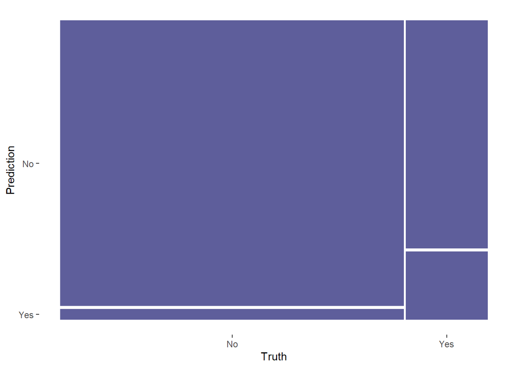

```r
#Visualise Results_RF
update_geom_defaults(geom = "rect", new = list(fill = "midnightblue", alpha = 0.7))
results_RF%>%
  conf_mat(GDDiag,.pred_class) %>%
  autoplot()
```

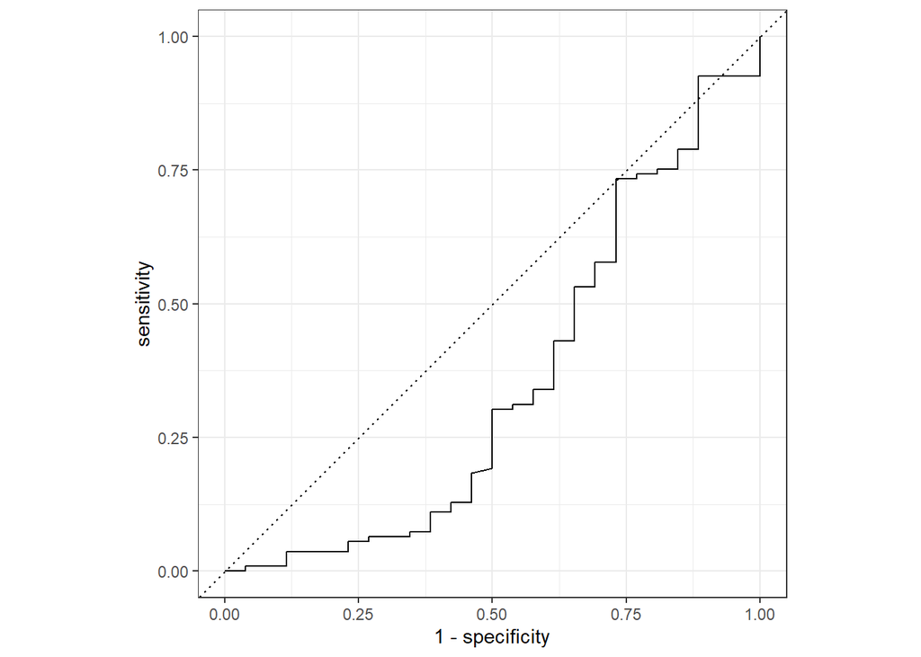

```r
#Metrics
ev_met1_RF<-ev_met1(results_RF,truth = GDDiag, estimate = .pred_class)
Rec_RF<-yardstick::recall(results_RF, GDDiag, .pred_class)
ACC_RF<-yardstick::accuracy(results_RF, GDDiag, .pred_class)
#Plot Roc_Curve
curve_RF <- results_RF %>%
  roc_curve(GDDiag, .pred_Yes) %>%
  autoplot
curve_RF
```

```r
#Evaluate AUC
auc_RF <- results_RF %>%
  roc_auc(GDDiag, .pred_Yes)
RFMET<-list(auc_RF,ev_met1_RF, Rec_RF, ACC_RF)
kable(RFMET)
```

| .metric | .estimator | .estimate |
| --- | --- | --- |
| roc_auc | binary | 0.35 |

| .metric | .estimator | .estimate |
| --- | --- | --- |
| ppv | binary | 0.840 |
| f_meas | binary | 0.897 |

| .metric | .estimator | .estimate |
| --- | --- | --- |
| recall | binary | 0.963 |

| .metric | .estimator | .estimate |
| --- | --- | --- |
| accuracy | binary | 0.822 |

```
## [[1]]
## [[1]][[1]]
## # A tibble: 1 x 3
##   .metric .estimator .estimate
##   <chr>   <chr>          <dbl>
## 1 roc_auc binary         0.350
##
## [[1]][[2]]
## # A tibble: 2 x 3
##   .metric .estimator .estimate
##   <chr>   <chr>          <dbl>
## 1 ppv     binary         0.84
## 2 f_meas  binary         0.897
##
## [[1]][[3]]
## # A tibble: 1 x 3
##   .metric .estimator .estimate
##   <chr>   <chr>          <dbl>
## 1 recall  binary         0.963
##
## [[1]][[4]]
## # A tibble: 1 x 3
##   .metric  .estimator .estimate
##   <chr>    <chr>          <dbl>
## 1 accuracy binary         0.822
##
##
## [[2]]
```

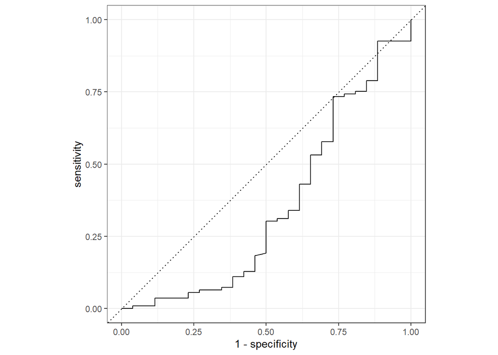

```r
RFMETCurVe<-list(RFMET, curve_RF)
RFMETCurVe
```

```r
#LogReg_Untuned_workflow

results_LR%>%
  conf_mat(truth = GDDiag, estimate = .pred_class)
```

```
##           Truth
## Prediction  No Yes
##        No  108  25
##        Yes   1   1
```

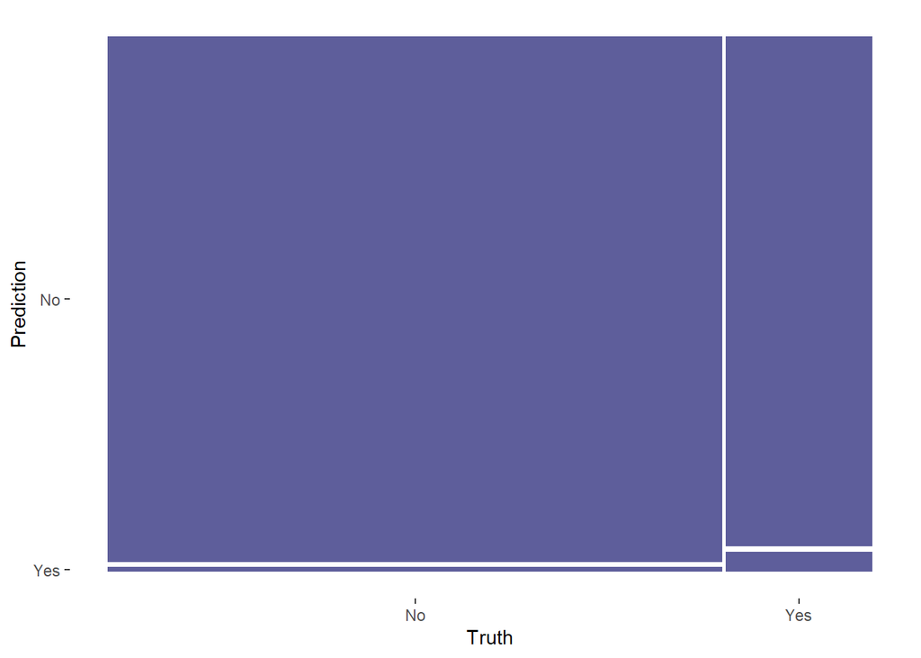

```r
#Visualise Results_RF
update_geom_defaults(geom = "rect", new = list(fill = "midnightblue", alpha = 0.7))
results_LR%>%
  conf_mat(GDDiag,.pred_class) %>%
  autoplot()
```

```r
#Metrics
ev_met1_LR<-ev_met1(results_LR,truth = GDDiag, estimate = .pred_class)
Rec_LR<-yardstick::recall(results_LR, GDDiag, .pred_class)
ACC_LR<-yardstick::accuracy(results_LR, GDDiag, .pred_class)
#Plot Roc_Curve
curve_LR <- results_LR %>%
  roc_curve(GDDiag, .pred_Yes) %>%
  autoplot
curve_LR
```

```r
#Evaluate AUC
auc_LR <- results_LR %>%
  roc_auc(GDDiag, .pred_Yes)
LRMET<-list(auc_LR,ev_met1_LR, Rec_LR, ACC_LR)
kable(LRMET)
```

| .metric | .estimator | .estimate |
| --- | --- | --- |
| roc_auc | binary | 0.351 |

| .metric | .estimator | .estimate |
| --- | --- | --- |
| ppv | binary | 0.812 |
| f_meas | binary | 0.893 |

| .metric | .estimator | .estimate |
| --- | --- | --- |
| recall | binary | 0.991 |

| .metric | .estimator | .estimate |
| --- | --- | --- |
| accuracy | binary | 0.807 |

```r
LRMETCurVe<-list(LRMET, curve_LR)
LRMETCurVe
```

```
## [[1]]
## [[1]][[1]]
## # A tibble: 1 x 3
##   .metric .estimator .estimate
##   <chr>   <chr>          <dbl>
## 1 roc_auc binary         0.351
##
## [[1]][[2]]
## # A tibble: 2 x 3
##   .metric .estimator .estimate
##   <chr>   <chr>          <dbl>
## 1 ppv     binary         0.812
## 2 f_meas  binary         0.893
##
## [[1]][[3]]
## # A tibble: 1 x 3
##   .metric .estimator .estimate
##   <chr>   <chr>          <dbl>
## 1 recall  binary         0.991
##
## [[1]][[4]]
## # A tibble: 1 x 3
##   .metric  .estimator .estimate
##   <chr>    <chr>          <dbl>
## 1 accuracy binary         0.807
##
##
## [[2]]
```

```r
#Kernel_SMV_Untuned
results_Kern%>%
  conf_mat(truth = GDDiag, estimate = .pred_class)
```

```
##           Truth
## Prediction  No Yes
##        No  109  26
##        Yes   0   0
```

```r
#Visualise Results_RF
update_geom_defaults(geom = "rect", new = list(fill = "midnightblue", alpha = 0.7))
results_Kern%>%
  conf_mat(GDDiag,.pred_class) %>%
  autoplot()
```

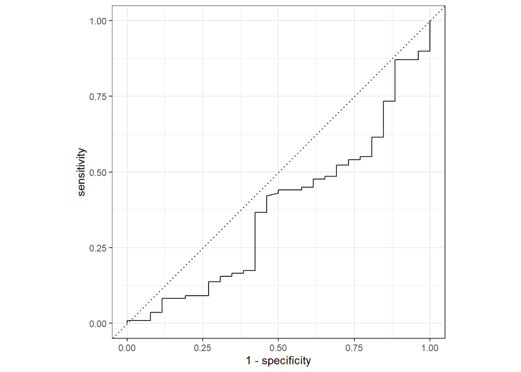

```r
#Metrics
ev_met1_Kern<-ev_met1(results_Kern,truth = GDDiag, estimate = .pred_class)
Rec_Kern<-yardstick::recall(results_Kern, GDDiag, .pred_class)
ACC_Kern<-yardstick::accuracy(results_Kern, GDDiag, .pred_class)
#Plot Roc_Curve
curve_Kern <- results_Kern %>%
  roc_curve(GDDiag, .pred_Yes) %>%
  autoplot
curve_Kern
```

```r
#Evaluate AUC
auc_Kern <- results_Kern %>%
  roc_auc(GDDiag, .pred_Yes)
KernMET<-list(auc_Kern,ev_met1_Kern, Rec_Kern, ACC_Kern)
kable(KernMET)
```

| .metric | .estimator | .estimate |
| --- | --- | --- |
| roc_auc | binary | 0.374 |

| .metric | .estimator | .estimate |
| --- | --- | --- |
| ppv | binary | 0.807 |
| f_meas | binary | 0.893 |

| .metric | .estimator | .estimate |
| --- | --- | --- |
| recall | binary | 1 |

| .metric | .estimator | .estimate |
| --- | --- | --- |
| accuracy | binary | 0.807 |

```r
KernMETCurVe<-list(KernMET, curve_LR)
KernMETCurVe
```

```
## [[1]]
## [[1]][[1]]
## # A tibble: 1 x 3
##   .metric .estimator .estimate
##   <chr>   <chr>          <dbl>
## 1 roc_auc binary         0.374
##
## [[1]][[2]]
## # A tibble: 2 x 3
##   .metric .estimator .estimate
##   <chr>   <chr>          <dbl>
## 1 ppv     binary         0.807
## 2 f_meas  binary         0.893
##
## [[1]][[3]]
## # A tibble: 1 x 3
##   .metric .estimator .estimate
##   <chr>   <chr>          <dbl>
## 1 recall  binary             1
##
## [[1]][[4]]
## # A tibble: 1 x 3
##   .metric  .estimator .estimate
##   <chr>    <chr>          <dbl>
## 1 accuracy binary         0.807
##
##
## [[2]]
```

```r
#NB_Untuned
results_NB%>%
  conf_mat(truth = GDDiag, estimate = .pred_class)
```

```
##           Truth
## Prediction  No Yes
##        No  105  22
##        Yes   4   4
```

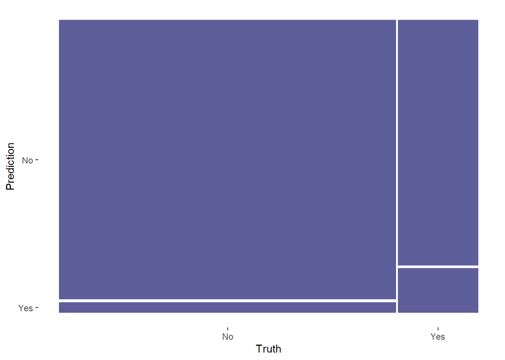

```r
#Visualise Results_RF
update_geom_defaults(geom = "rect", new = list(fill = "midnightblue", alpha = 0.7))
results_NB%>%
  conf_mat(GDDiag,.pred_class) %>%
  autoplot()
```

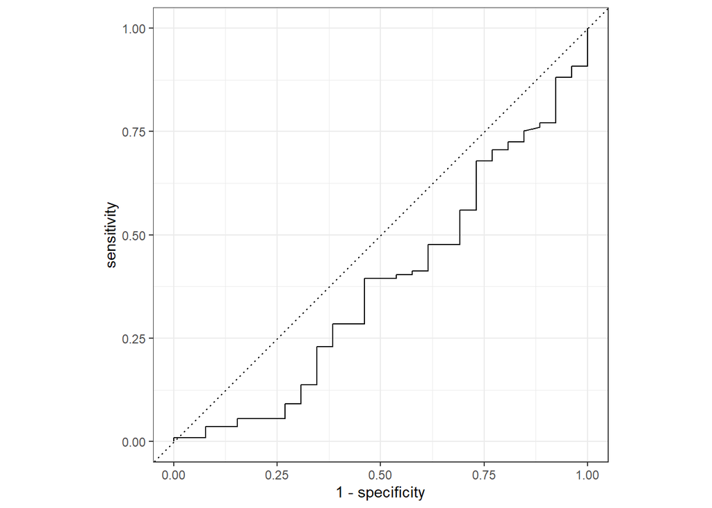

```r
#Metrics
ev_met1_NB<-ev_met1(results_NB,truth = GDDiag, estimate = .pred_class)
Rec_NB<-yardstick::recall(results_NB, GDDiag, .pred_class)
ACC_NB<-yardstick::accuracy(results_NB, GDDiag, .pred_class)
#Plot Roc_Curve
curve_NB <- results_NB %>%
  roc_curve(GDDiag, .pred_Yes) %>%
  autoplot
curve_NB
```

```r
#Evaluate AUC
auc_NB <- results_NB %>%
  roc_auc(GDDiag, .pred_Yes)
NBMET<-list(auc_NB,ev_met1_NB, Rec_NB, ACC_NB)
kable(NBMET)
```

| .metric | .estimator | .estimate |
| --- | --- | --- |
| roc_auc | binary | 0.378 |

| .metric | .estimator | .estimate |
| --- | --- | --- |
| ppv | binary | 0.827 |
| f_meas | binary | 0.890 |

| .metric | .estimator | .estimate |
| --- | --- | --- |
| recall | binary | 0.963 |

| .metric | .estimator | .estimate |
| --- | --- | --- |
| accuracy | binary | 0.807 |

```
## [[1]]
## [[1]][[1]]
## # A tibble: 1 x 3
##   .metric .estimator .estimate
##   <chr>   <chr>          <dbl>
## 1 roc_auc binary         0.378
##
## [[1]][[2]]
## # A tibble: 2 x 3
##   .metric .estimator .estimate
##   <chr>   <chr>          <dbl>
## 1 ppv     binary         0.827
## 2 f_meas  binary         0.890
##
## [[1]][[3]]
## # A tibble: 1 x 3
##   .metric .estimator .estimate
##   <chr>   <chr>          <dbl>
## 1 recall  binary         0.963
##
## [[1]][[4]]
## # A tibble: 1 x 3
##   .metric  .estimator .estimate
##   <chr>    <chr>          <dbl>
## 1 accuracy binary         0.807
##
##
## [[2]]
```

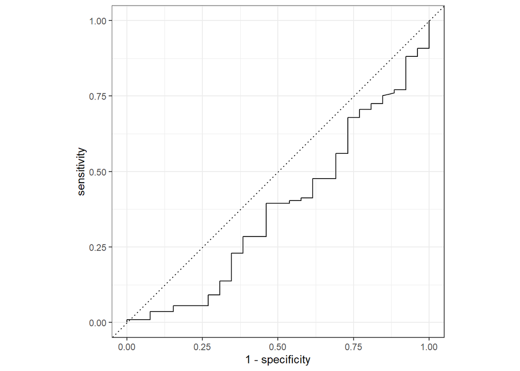

```r
NBMETCurVe<-list(NBMET, curve_NB)
NBMETCurVe
```

Fitting the different workflows on the testing data and extracting the most importnat recipe predictors for the different workflows for models available

```r
echo=FALSE
error=FALSE
warning=FALSE
options(scipen = 999, digits=3, max.print=999999, show.signif.stars=TRUE)
Null_fit_Test<-Null_workflow%>%fit(test_data_GD_b)
Null_fit_Test
```

```
## == Workflow [trained] ==========================================================
## Preprocessor: Recipe
## Model: null_model()
##
## -- Preprocessor ----------------------------------------------------------------
## 8 Recipe Steps
##
## * step_smote()
## * step_dummy()
## * step_zv()
## * step_nzv()
## * step_corr()
## * step_center()
## * step_scale()
## * step_normalize()
##
## -- Model -----------------------------------------------------------------------
## Null Regression Model
## Predicted Value: No
```

```r
Lasso_fit_Test<-lasso_workflow%>%fit(test_data_GD_b)
Lasso_fit_Test
```

```
## == Workflow [trained] ==========================================================
## Preprocessor: Recipe
## Model: multinom_reg()
##
## -- Preprocessor ----------------------------------------------------------------
## 8 Recipe Steps
##
## * step_smote()
## * step_dummy()
## * step_zv()
## * step_nzv()
## * step_corr()
## * step_center()
## * step_scale()
## * step_normalize()
##
## -- Model -----------------------------------------------------------------------
##
## Call:  glmnet::glmnet(x = maybe_matrix(x), y = y, family = "multinomial",      alpha = ~1)
##
##    Df %Dev Lambda
## 1   0 0.00 0.0458
## 2   2 0.64 0.0417
## 3   2 1.31 0.0380
## 4   2 1.87 0.0346
## 5   2 2.34 0.0315
## 6   2 2.73 0.0287
## 7   2 3.05 0.0262
## 8   2 3.33 0.0239
## 9   2 3.55 0.0217
## 10  2 3.74 0.0198
## 11  2 3.90 0.0181
## 12  2 4.04 0.0165
## 13  2 4.15 0.0150
## 14  2 4.24 0.0137
## 15  2 4.32 0.0124
## 16  2 4.39 0.0113
## 17  2 4.44 0.0103
## 18  2 4.49 0.0094
## 19  2 4.52 0.0086
```

[output cut: 8 more lines]

```
## 28  4 4.73 0.0037
## 29  4 4.75 0.0034
## 30  4 4.75 0.0031
## 31  4 4.76 0.0028
## 32  4 4.77 0.0026
## 33  4 4.77 0.0023
## 34  4 4.78 0.0021
## 35  4 4.78 0.0019
## 36  4 4.78 0.0018
## 37  4 4.79 0.0016
## 38  4 4.79 0.0015
## 39  4 4.79 0.0013
## 40  4 4.79 0.0012
## 41  4 4.79 0.0011
## 42  4 4.79 0.0010
```

```r
RF_fit_Test<-RF_workflow%>%fit(test_data_GD_b)
RF_fit_Test
```

```
## == Workflow [trained] ==========================================================
## Preprocessor: Recipe
## Model: rand_forest()
##
## -- Preprocessor ----------------------------------------------------------------
## 8 Recipe Steps
##
## * step_smote()
## * step_dummy()
## * step_zv()
## * step_nzv()
## * step_corr()
## * step_center()
## * step_scale()
## * step_normalize()
##
## -- Model -----------------------------------------------------------------------
## Ranger result
##
## Call:
##  ranger::ranger(x = maybe_data_frame(x), y = y, importance = ~"impurity",      num.threads = 1, verbose = FALSE, seed = sample.int(10^5,          1), probability = TRUE)
##
## Type:                             Probability estimation
## Number of trees:                  500
## Sample size:                      136
## Number of independent variables:  4
## Mtry:                             2
## Target node size:                 10
## Variable importance mode:         impurity
## Splitrule:                        gini
## OOB prediction error (Brier s.):  0.165
```

```r
LogReg_fit_Test<-LOGGLM_workflow%>%fit(test_data_GD_b)
LogReg_fit_Test
```

```
## == Workflow [trained] ==========================================================
## Preprocessor: Recipe
## Model: logistic_reg()
##
## -- Preprocessor ----------------------------------------------------------------
## 8 Recipe Steps
##
## * step_smote()
## * step_dummy()
## * step_zv()
## * step_nzv()
## * step_corr()
## * step_center()
## * step_scale()
## * step_normalize()
##
## -- Model -----------------------------------------------------------------------
##
## Call:  stats::glm(formula = ..y ~ ., family = stats::binomial, data = data)
##
## Coefficients:
## (Intercept)      IDTotal      IMTotal    COMPTotal      PETotal
##     -1.4889      -0.5355       0.5522      -0.0804       0.0392
##
## Degrees of Freedom: 135 Total (i.e. Null);  131 Residual
## Null Deviance:       136
## Residual Deviance: 129   AIC: 139
```

```r
Kernel_fit_Test<-Kernel_workflow%>%fit(test_data_GD_b)
```

```
## maximum number of iterations reached -0.000285 -0.000288
```

```r
Kernel_fit_Test
```

```
## == Workflow [trained] ==========================================================
## Preprocessor: Recipe
## Model: svm_rbf()
##
## -- Preprocessor ----------------------------------------------------------------
## 8 Recipe Steps
##
## * step_smote()
## * step_dummy()
## * step_zv()
## * step_nzv()
## * step_corr()
## * step_center()
## * step_scale()
## * step_normalize()
##
## -- Model -----------------------------------------------------------------------
## Support Vector Machine object of class "ksvm"
##
## SV type: C-svc  (classification)
##  parameter : cost C = 1
##
## Gaussian Radial Basis kernel function.
##  Hyperparameter : sigma =  0.01
##
## Number of Support Vectors : 71
##
## Objective Function Value : -54
## Training error : 0.198529
## Probability model included.
```

```r
NB_fit_Test<-NB_workflow%>%fit(test_data_GD_b)
NB_fit_Test
```

```
## == Workflow [trained] ==========================================================
## Preprocessor: Recipe
## Model: naive_Bayes()
##
## -- Preprocessor ----------------------------------------------------------------
## 8 Recipe Steps
##
## * step_smote()
## * step_dummy()
## * step_zv()
## * step_nzv()
## * step_corr()
## * step_center()
## * step_scale()
## * step_normalize()
##
## -- Model -----------------------------------------------------------------------
##
## ================================== Naive Bayes ==================================
##
##  Call:
## naive_bayes.default(x = maybe_data_frame(x), y = y, usekernel = TRUE)
##
## ---------------------------------------------------------------------------------
##
## Laplace smoothing: 0
##
## ---------------------------------------------------------------------------------
##
##  A priori probabilities:
##
##    No   Yes
## 0.801 0.199
##
## ---------------------------------------------------------------------------------
##
##  Tables:
##
## ---------------------------------------------------------------------------------
##  ::: IDTotal::No (KDE)
```

[output cut: 15 more lines]

```
## ---------------------------------------------------------------------------------
##  ::: IDTotal::Yes (KDE)
## ---------------------------------------------------------------------------------
##
## Call:
##  density.default(x = x, na.rm = TRUE)
##
## Data: x (27 obs.);   Bandwidth 'bw' = 0.5058
##
##        x               y
##  Min.   :-3.06   Min.   :0.0003
##  1st Qu.:-1.37   1st Qu.:0.0268
##
## ...
## and 109 more lines.
```

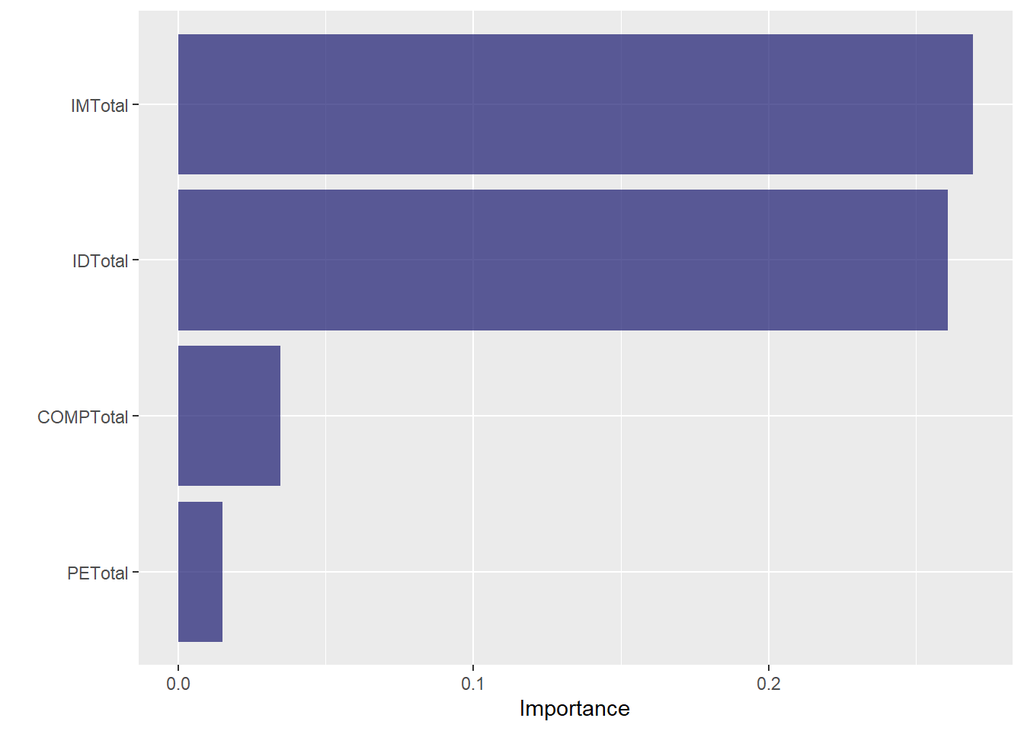

```r
Lasso_fit_Test %>%
  extract_fit_parsnip() %>%
 #Make VIP plot
 vip()
```

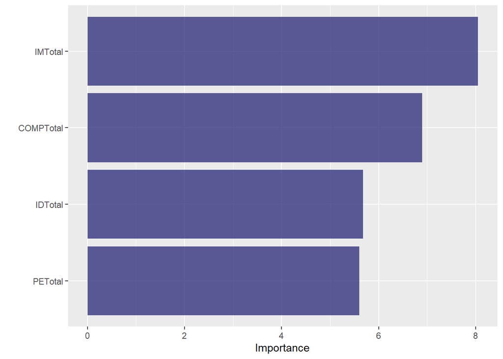

```r
RF_fit_Test %>%
  extract_fit_parsnip() %>%
 #Make VIP plot
 vip()
```

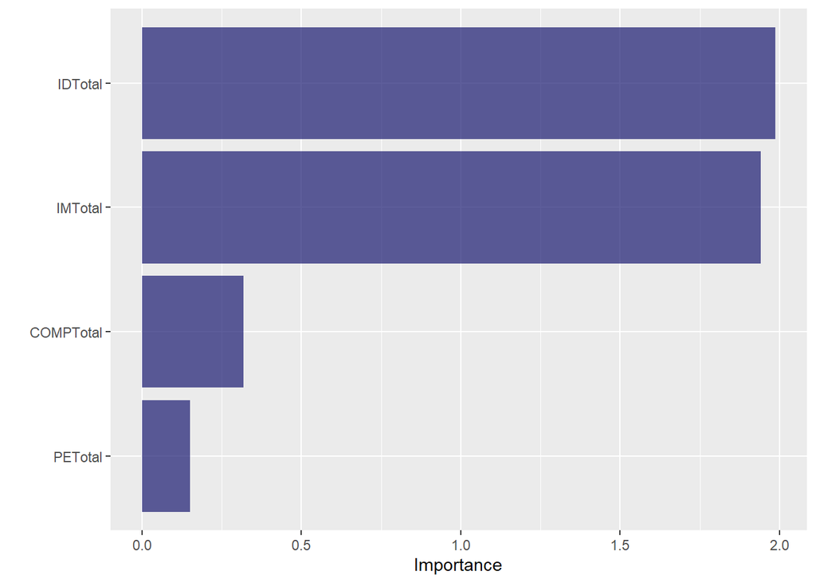

```r
LogReg_fit_Test %>%
  extract_fit_parsnip() %>%
 #Make VIP plot
 vip()
```

Tune Tunable Predictors RF, Kernel, Lasso, Logistic Regression

#Tune Kernel Algorithm

```r
echo=FALSE
error=FALSE
warning=FALSE
options(scipen = 999, digits=3, max.print=999999, show.signif.stars=TRUE)
set.seed(123)
#Kernel
#first creating a tuning model
svm_spec_T <- svm_rbf(mode = "classification", engine = "kernlab", cost = tune(), rbf_sigma = tune())
#second creating a tuning workflow
Kernel_workflow_T<-workflow() %>%
  add_recipe(GD_rec) %>%
  add_model(svm_spec_T)
#third calling the workflow
Kernel_workflow_T
```

```
## == Workflow ====================================================================
## Preprocessor: Recipe
## Model: svm_rbf()
##
## -- Preprocessor ----------------------------------------------------------------
## 8 Recipe Steps
##
## * step_smote()
## * step_dummy()
## * step_zv()
## * step_nzv()
## * step_corr()
## * step_center()
## * step_scale()
## * step_normalize()
##
## -- Model -----------------------------------------------------------------------
## Radial Basis Function Support Vector Machine Model Specification (classification)
##
## Main Arguments:
##   cost = tune()
##   rbf_sigma = tune()
##
## Computational engine: kernlab
```

```r
# fourth creating the regular grid of 6 values for each tuning parameters
svm_grid <- grid_regular(parameters(svm_spec_T), levels = 10)
#fifth calling the grid
svm_grid
```

```
## # A tibble: 100 x 2
##         cost    rbf_sigma
##        <dbl>        <dbl>
##  1  0.000977 0.0000000001
##  2  0.00310  0.0000000001
##  3  0.00984  0.0000000001
##  4  0.0312   0.0000000001
##  5  0.0992   0.0000000001
##  6  0.315    0.0000000001
##  7  1        0.0000000001
##  8  3.17     0.0000000001
##  9 10.1      0.0000000001
## 10 32        0.0000000001
## # i 90 more rows
```

```r
#sixth tuning the grid
svm_res <- tune_grid(
  object = Kernel_workflow_T,resamples = train_boot,
  grid = svm_grid
)
```

```r
#Seventh collect tuning metrics
svm_res %>%
  collect_metrics() %>%
  slice_head(n = 20)
```

```
## # A tibble: 20 x 8
##         cost    rbf_sigma .metric  .estimator  mean     n std_err .config
##        <dbl>        <dbl> <chr>    <chr>      <dbl> <int>   <dbl> <chr>
##  1  0.000977 0.0000000001 accuracy binary     0.806    25 0.00244 Preprocessor1~
##  2  0.000977 0.0000000001 roc_auc  binary     0.517    25 0.0124  Preprocessor1~
##  3  0.00310  0.0000000001 accuracy binary     0.806    25 0.00244 Preprocessor1~
##  4  0.00310  0.0000000001 roc_auc  binary     0.517    25 0.0124  Preprocessor1~
##  5  0.00984  0.0000000001 accuracy binary     0.806    25 0.00244 Preprocessor1~
##  6  0.00984  0.0000000001 roc_auc  binary     0.517    25 0.0124  Preprocessor1~
##  7  0.0312   0.0000000001 accuracy binary     0.806    25 0.00244 Preprocessor1~
##  8  0.0312   0.0000000001 roc_auc  binary     0.517    25 0.0124  Preprocessor1~
##  9  0.0992   0.0000000001 accuracy binary     0.806    25 0.00244 Preprocessor1~
## 10  0.0992   0.0000000001 roc_auc  binary     0.517    25 0.0124  Preprocessor1~
## 11  0.315    0.0000000001 accuracy binary     0.806    25 0.00244 Preprocessor1~
## 12  0.315    0.0000000001 roc_auc  binary     0.517    25 0.0124  Preprocessor1~
## 13  1        0.0000000001 accuracy binary     0.806    25 0.00244 Preprocessor1~
## 14  1        0.0000000001 roc_auc  binary     0.517    25 0.0124  Preprocessor1~
## 15  3.17     0.0000000001 accuracy binary     0.806    25 0.00244 Preprocessor1~
## 16  3.17     0.0000000001 roc_auc  binary     0.517    25 0.0124  Preprocessor1~
## 17 10.1      0.0000000001 accuracy binary     0.806    25 0.00244 Preprocessor1~
## 18 10.1      0.0000000001 roc_auc  binary     0.517    25 0.0124  Preprocessor1~
## 19 32        0.0000000001 accuracy binary     0.806    25 0.00244 Preprocessor1~
## 20 32        0.0000000001 roc_auc  binary     0.517    25 0.0124  Preprocessor1~
```

```r
  #show_best()
```

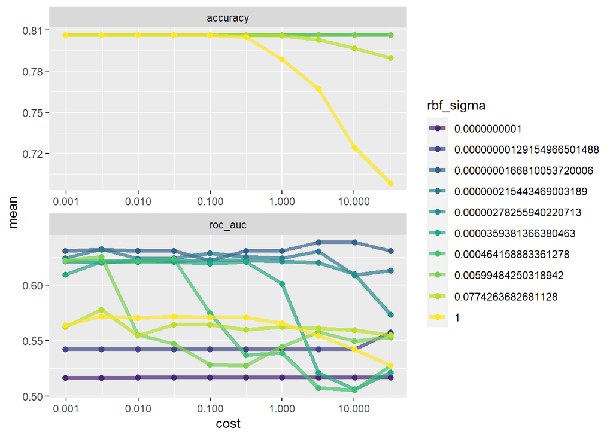

```r
  #Eighth Visualizing Tuning Metrics

svm_res %>%
  collect_metrics() %>%
  mutate(rbf_sigma = factor(rbf_sigma)) %>%
  ggplot(mapping = aes(x = cost, y = mean, color = rbf_sigma)) +
  geom_line(size = 1.5, alpha = 0.7) +
  geom_point(size = 2) +
  facet_wrap(~.metric, scales = "free", nrow = 2) +
  scale_x_log10(labels = scales::label_number()) +
  scale_color_viridis_d(option = "viridis", begin = .1)
```

```r
#Nineth show the best model
svm_res %>%
  show_best("accuracy")
```

```
## # A tibble: 5 x 8
##       cost    rbf_sigma .metric  .estimator  mean     n std_err .config
##      <dbl>        <dbl> <chr>    <chr>      <dbl> <int>   <dbl> <chr>
## 1 0.000977 0.0000000001 accuracy binary     0.806    25 0.00244 Preprocessor1_M~
## 2 0.00310  0.0000000001 accuracy binary     0.806    25 0.00244 Preprocessor1_M~
## 3 0.00984  0.0000000001 accuracy binary     0.806    25 0.00244 Preprocessor1_M~
## 4 0.0312   0.0000000001 accuracy binary     0.806    25 0.00244 Preprocessor1_M~
## 5 0.0992   0.0000000001 accuracy binary     0.806    25 0.00244 Preprocessor1_M~
```

```r
svm_res%>%
  show_best("roc_auc")
```

```
## # A tibble: 5 x 8
##       cost    rbf_sigma .metric .estimator  mean     n std_err .config
##      <dbl>        <dbl> <chr>   <chr>      <dbl> <int>   <dbl> <chr>
## 1 10.1     0.0000000167 roc_auc binary     0.638    25  0.0104 Preprocessor1_Mo~
## 2  3.17    0.0000000167 roc_auc binary     0.638    25  0.0113 Preprocessor1_Mo~
## 3  0.00310 0.000000215  roc_auc binary     0.632    25  0.0110 Preprocessor1_Mo~
## 4  0.00310 0.0000000167 roc_auc binary     0.632    25  0.0107 Preprocessor1_Mo~
## 5 32       0.0000000167 roc_auc binary     0.631    25  0.0107 Preprocessor1_Mo~
```

```r
# Tenth Select best model hyperparameters
best_svm <- svm_res %>%
  select_best("accuracy", "roc_auc")
#11th Finalize the workoflow with the best SVM
final_wflow <- Kernel_workflow_T %>%
  finalize_workflow(best_svm)
#12th Check the fit of the final Wflow on the training data
Tuned_Kernel_fit<-final_wflow%>%fit(train_data_GD_b)
Tuned_Kernel_fit
```

```
## == Workflow [trained] ==========================================================
## Preprocessor: Recipe
## Model: svm_rbf()
##
## -- Preprocessor ----------------------------------------------------------------
## 8 Recipe Steps
##
## * step_smote()
## * step_dummy()
## * step_zv()
## * step_nzv()
## * step_corr()
## * step_center()
## * step_scale()
## * step_normalize()
##
## -- Model -----------------------------------------------------------------------
## Support Vector Machine object of class "ksvm"
##
## SV type: C-svc  (classification)
##  parameter : cost C = 0.0009765625
##
## Gaussian Radial Basis kernel function.
##  Hyperparameter : sigma =  0.0000000001
##
## Number of Support Vectors : 162
##
## Objective Function Value : -0.158
## Training error : 0.199507
## Probability model included.
```

```r
#Test the tuned Kernel on the test data
results_tuned_Kern<-test_data_GD_b %>% select(GDDiag) %>%
  bind_cols (Tuned_Kernel_fit%>%
              predict(new_data = test_data_GD_b)) %>%
  bind_cols(Tuned_Kernel_fit%>%
              predict(new_data = test_data_GD_b, type = "prob"))
kable(results_tuned_Kern)
```

| GDDiag | .pred_class | .pred_No | .pred_Yes |
| --- | --- | --- | --- |
| Yes | No | 0.8 | 0.2 |
| No | No | 0.8 | 0.2 |
| No | No | 0.8 | 0.2 |
| No | No | 0.8 | 0.2 |
| No | No | 0.8 | 0.2 |
| No | No | 0.8 | 0.2 |
| No | No | 0.8 | 0.2 |
| No | No | 0.8 | 0.2 |
| No | No | 0.8 | 0.2 |
| No | No | 0.8 | 0.2 |
| No | No | 0.8 | 0.2 |
| No | No | 0.8 | 0.2 |
| No | No | 0.8 | 0.2 |
| No | No | 0.8 | 0.2 |
| No | No | 0.8 | 0.2 |
| No | No | 0.8 | 0.2 |
| No | No | 0.8 | 0.2 |
| No | No | 0.8 | 0.2 |
| No | No | 0.8 | 0.2 |
| No | No | 0.8 | 0.2 |
| No | No | 0.8 | 0.2 |
| No | No | 0.8 | 0.2 |
| No | No | 0.8 | 0.2 |
| No | No | 0.8 | 0.2 |
| No | No | 0.8 | 0.2 |
| No | No | 0.8 | 0.2 |
| No | No | 0.8 | 0.2 |
| No | No | 0.8 | 0.2 |
| Yes | No | 0.8 | 0.2 |
| No | No | 0.8 | 0.2 |

[output cut: 105 more lines]

```r
#Tuned Kernel_Results
results_tuned_Kern %>%
  conf_mat(truth = GDDiag, estimate = .pred_class)
```

```
##           Truth
## Prediction  No Yes
##        No  109  26
##        Yes   0   0
```

```r
#visualise CF
update_geom_defaults(geom = "rect", new = list(fill = "midnightblue", alpha = 0.7))
results_tuned_Kern %>%
  conf_mat(GDDiag, .pred_class) %>%
  autoplot()
```

[output not shown]

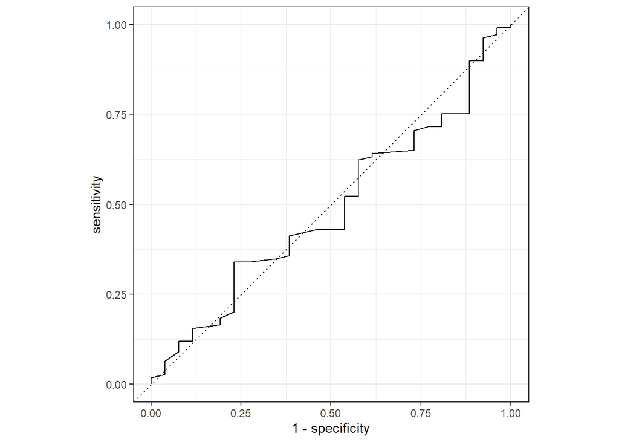

```r
#Plot Roc_Curve
curve_kern_tuned <- results_tuned_Kern%>%
  roc_curve(GDDiag, .pred_Yes)%>%
  autoplot

curve_kern_tuned
```

```r
# Evaluate ROC_AUC
auc_kern_tuned <- results_tuned_Kern %>%
  roc_auc(GDDiag, .pred_Yes)
auc_kern_tuned
```

```
## # A tibble: 1 x 3
##   .metric .estimator .estimate
##   <chr>   <chr>          <dbl>
## 1 roc_auc binary         0.489
```

```r
#AUC, PPV, ACC, Recall, Fmeas
ev_met1_TunKern<-ev_met1(results_tuned_Kern,truth = GDDiag, estimate = .pred_class)
Rec_TK<-yardstick::recall(results_tuned_Kern, GDDiag, .pred_class)
ACC_TK<-yardstick::accuracy(results_tuned_Kern, GDDiag, .pred_class)
TunKernMET<-list(auc_kern_tuned,ev_met1_TunKern, Rec_TK, ACC_TK)
kable(TunKernMET)
```

| .metric | .estimator | .estimate |
| --- | --- | --- |
| roc_auc | binary | 0.489 |

| .metric | .estimator | .estimate |
| --- | --- | --- |
| ppv | binary | 0.807 |
| f_meas | binary | 0.893 |

| .metric | .estimator | .estimate |
| --- | --- | --- |
| recall | binary | 1 |

| .metric | .estimator | .estimate |
| --- | --- | --- |
| accuracy | binary | 0.807 |

Tune Random Forests

```r
set.seed(123)
#RF
#first creating a tuning model
ranger_spec_T <- rand_forest(
  mtry = tune(),
  trees = 1000,
  min_n = tune()
)%>%
  set_mode("classification")%>%
  set_engine("ranger")
#second creating a tuning workflow
RF_workflow_T<-workflow() %>%
  add_recipe(GD_rec) %>%
  add_model(ranger_spec_T)
#third calling the workflow
RF_workflow_T
```

```
## == Workflow ====================================================================
## Preprocessor: Recipe
## Model: rand_forest()
##
## -- Preprocessor ----------------------------------------------------------------
## 8 Recipe Steps
##
## * step_smote()
## * step_dummy()
## * step_zv()
## * step_nzv()
## * step_corr()
## * step_center()
## * step_scale()
## * step_normalize()
##
## -- Model -----------------------------------------------------------------------
## Random Forest Model Specification (classification)
##
## Main Arguments:
##   mtry = tune()
##   trees = 1000
##   min_n = tune()
##
## Computational engine: ranger
```

```r
# fourth tuning/testing the workflow to the resamples
set.seed(345)
RF_res <- tune_grid(
  RF_workflow_T,
  resamples = train_boot,
  grid = 20
)
```

```
## i Creating pre-processing data to finalize unknown parameter: mtry
```

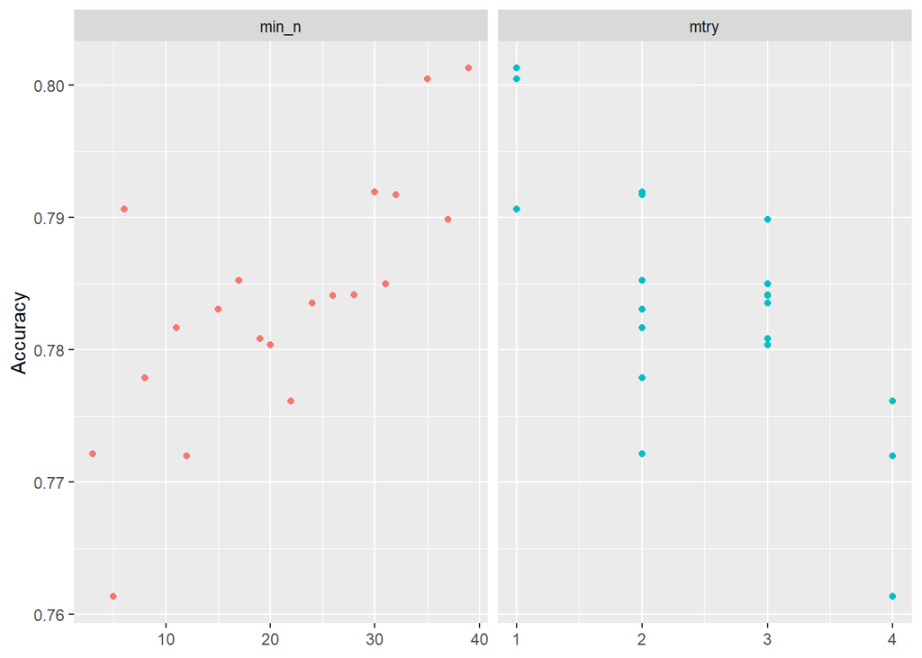

```r
#Fifth collect and visualize tuning metrics
RF_res %>%
  collect_metrics() %>%
  filter(.metric == "accuracy") %>%
  select(mean, min_n, mtry) %>%
  pivot_longer(min_n:mtry,
    values_to = "value",
    names_to = "parameter"
  )%>%
  ggplot(aes(value, mean, color = parameter)) +
  geom_point(show.legend = FALSE) +
  facet_wrap(~parameter, scales = "free_x") +
  labs(x = NULL, y = "Accuracy")
```

```r
#Fifth for collecting tuning metrics
RF_res %>%
  collect_metrics() %>%
  slice_head(n = 10)
```

```
## # A tibble: 10 x 8
##     mtry min_n .metric  .estimator  mean     n std_err .config
##    <int> <int> <chr>    <chr>      <dbl> <int>   <dbl> <chr>
##  1     1    35 accuracy binary     0.800    25 0.00394 Preprocessor1_Model01
##  2     1    35 roc_auc  binary     0.581    25 0.0102  Preprocessor1_Model01
##  3     3    19 accuracy binary     0.781    25 0.00475 Preprocessor1_Model02
##  4     3    19 roc_auc  binary     0.575    25 0.0109  Preprocessor1_Model02
##  5     3    37 accuracy binary     0.790    25 0.00407 Preprocessor1_Model03
##  6     3    37 roc_auc  binary     0.588    25 0.0106  Preprocessor1_Model03
##  7     3    20 accuracy binary     0.780    25 0.00467 Preprocessor1_Model04
##  8     3    20 roc_auc  binary     0.577    25 0.0107  Preprocessor1_Model04
##  9     2    32 accuracy binary     0.792    25 0.00410 Preprocessor1_Model05
## 10     2    32 roc_auc  binary     0.586    25 0.0106  Preprocessor1_Model05
```

```r
#Nineth show the best model
RF_res %>%
  show_best("accuracy", "roc_auc")
```

```
## # A tibble: 20 x 8
##     mtry min_n .metric  .estimator  mean     n std_err .config
##    <int> <int> <chr>    <chr>      <dbl> <int>   <dbl> <chr>
##  1     1    39 accuracy binary     0.801    25 0.00381 Preprocessor1_Model07
##  2     1    35 accuracy binary     0.800    25 0.00394 Preprocessor1_Model01
##  3     2    30 accuracy binary     0.792    25 0.00402 Preprocessor1_Model11
##  4     2    32 accuracy binary     0.792    25 0.00410 Preprocessor1_Model05
##  5     1     6 accuracy binary     0.791    25 0.00383 Preprocessor1_Model08
##  6     3    37 accuracy binary     0.790    25 0.00407 Preprocessor1_Model03
##  7     2    17 accuracy binary     0.785    25 0.00406 Preprocessor1_Model06
##  8     3    31 accuracy binary     0.785    25 0.00419 Preprocessor1_Model10
##  9     3    28 accuracy binary     0.784    25 0.00390 Preprocessor1_Model09
## 10     3    26 accuracy binary     0.784    25 0.00444 Preprocessor1_Model12
## 11     3    24 accuracy binary     0.784    25 0.00412 Preprocessor1_Model15
## 12     2    15 accuracy binary     0.783    25 0.00436 Preprocessor1_Model17
## 13     2    11 accuracy binary     0.782    25 0.00474 Preprocessor1_Model13
## 14     3    19 accuracy binary     0.781    25 0.00475 Preprocessor1_Model02
## 15     3    20 accuracy binary     0.780    25 0.00467 Preprocessor1_Model04
## 16     2     8 accuracy binary     0.778    25 0.00505 Preprocessor1_Model19
## 17     4    22 accuracy binary     0.776    25 0.00522 Preprocessor1_Model16
## 18     2     3 accuracy binary     0.772    25 0.00513 Preprocessor1_Model14
## 19     4    12 accuracy binary     0.772    25 0.00536 Preprocessor1_Model20
## 20     4     5 accuracy binary     0.761    25 0.00589 Preprocessor1_Model18
```

```r
# Tenth Select best model hyperparameters
best_RF <- RF_res %>%
  select_best("accuracy", "roc_auc")
best_RF
```

```
## # A tibble: 1 x 3
##    mtry min_n .config
##   <int> <int> <chr>
## 1     1    39 Preprocessor1_Model07
```

```r
#11th Finalize the workoflow with the best SVM
final_wflow_RF <- RF_workflow_T %>%
  finalize_workflow(best_RF)
#12th Check the fit of the final Wflow on the training data
Tuned_RF_fit<-final_wflow_RF%>%fit(train_data_GD_b)
Tuned_RF_fit
```

```
## == Workflow [trained] ==========================================================
## Preprocessor: Recipe
## Model: rand_forest()
##
## -- Preprocessor ----------------------------------------------------------------
## 8 Recipe Steps
##
## * step_smote()
## * step_dummy()
## * step_zv()
## * step_nzv()
## * step_corr()
## * step_center()
## * step_scale()
## * step_normalize()
##
## -- Model -----------------------------------------------------------------------
## Ranger result
##
## Call:
##  ranger::ranger(x = maybe_data_frame(x), y = y, mtry = min_cols(~1L,      x), num.trees = ~1000, min.node.size = min_rows(~39L, x),      num.threads = 1, verbose = FALSE, seed = sample.int(10^5,          1), probability = TRUE)
##
## Type:                             Probability estimation
## Number of trees:                  1000
## Sample size:                      406
## Number of independent variables:  4
## Mtry:                             1
## Target node size:                 39
## Variable importance mode:         none
## Splitrule:                        gini
## OOB prediction error (Brier s.):  0.157
```

```r
#Test the tuned RF on the test data
results_tuned_RF<-test_data_GD_b %>% select(GDDiag) %>%
  bind_cols (Tuned_RF_fit%>%
              predict(new_data = test_data_GD_b)) %>%
  bind_cols(Tuned_RF_fit%>%
              predict(new_data = test_data_GD_b, type = "prob"))
kable(results_tuned_RF)
```

| GDDiag | .pred_class | .pred_No | .pred_Yes |
| --- | --- | --- | --- |
| Yes | No | 0.572 | 0.428 |
| No | No | 0.847 | 0.153 |
| No | No | 0.842 | 0.158 |
| No | No | 0.921 | 0.079 |
| No | No | 0.861 | 0.139 |
| No | No | 0.695 | 0.305 |
| No | No | 0.744 | 0.256 |
| No | No | 0.783 | 0.217 |
| No | No | 0.873 | 0.127 |
| No | No | 0.693 | 0.307 |
| No | No | 0.878 | 0.122 |
| No | No | 0.828 | 0.172 |
| No | No | 0.894 | 0.106 |
| No | No | 0.839 | 0.161 |
| No | No | 0.810 | 0.190 |
| No | Yes | 0.478 | 0.522 |
| No | No | 0.703 | 0.297 |
| No | No | 0.953 | 0.047 |
| No | No | 0.936 | 0.064 |
| No | No | 0.842 | 0.158 |
| No | No | 0.828 | 0.172 |
| No | No | 0.763 | 0.237 |
| No | No | 0.828 | 0.172 |
| No | No | 0.804 | 0.196 |
| No | No | 0.809 | 0.191 |
| No | No | 0.706 | 0.294 |
| No | No | 0.774 | 0.226 |
| No | No | 0.809 | 0.191 |
| Yes | Yes | 0.489 | 0.511 |
| No | No | 0.804 | 0.196 |

[output cut: 105 more lines]

```r
#Tuned RF_Results
results_tuned_RF %>%
  conf_mat(truth = GDDiag, estimate = .pred_class)
```

```
##           Truth
## Prediction  No Yes
##        No  108  25
##        Yes   1   1
```

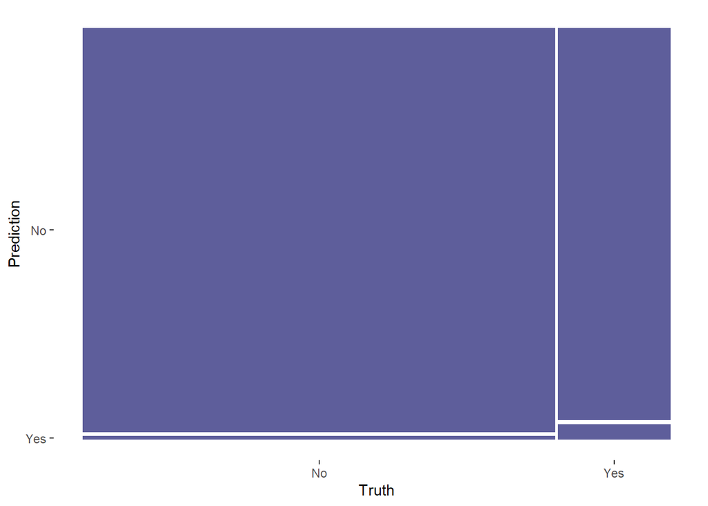

```r
#visualise CF
update_geom_defaults(geom = "rect", new = list(fill = "midnightblue", alpha = 0.7))
results_tuned_RF %>%
  conf_mat(GDDiag, .pred_class) %>%
  autoplot()
```

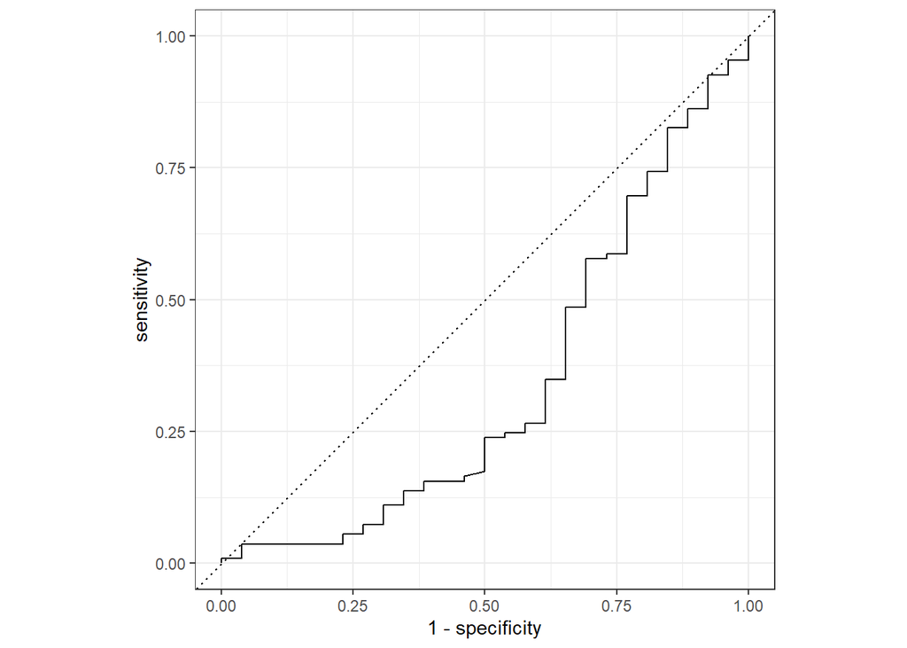

```r
#Plot Roc_Curve
curve_RF_tuned <- results_tuned_RF %>%
  roc_curve(GDDiag, .pred_Yes) %>%
  autoplot
curve_RF_tuned
```

```r
# Evaluate ROC_AOC
auc_RF_tuned <- results_tuned_RF %>%
  roc_auc(GDDiag, .pred_Yes)
ev_met1_TunRF<-ev_met1(results_tuned_RF,truth = GDDiag, estimate = .pred_class)
Rec_TRF<-yardstick::recall(results_tuned_RF, GDDiag, .pred_class)
ACC_TRF<-yardstick::accuracy(results_tuned_RF, GDDiag, .pred_class)
TunRFMET<-list(auc_RF_tuned,ev_met1_TunRF, Rec_TRF, ACC_TRF)
kable(TunRFMET)
```

| .metric | .estimator | .estimate |
| --- | --- | --- |
| roc_auc | binary | 0.339 |

| .metric | .estimator | .estimate |
| --- | --- | --- |
| ppv | binary | 0.812 |
| f_meas | binary | 0.893 |

| .metric | .estimator | .estimate |
| --- | --- | --- |
| recall | binary | 0.991 |

| .metric | .estimator | .estimate |
| --- | --- | --- |
| accuracy | binary | 0.807 |

#Tune Lasso

```r
set.seed(123)
#LASSO

#first creating a tuning model
tune_Lasso <- multinom_reg(penalty =tune(), mixture = 1)%>%
  set_mode("classification")%>%
  set_engine("glmnet")

#second creating a tuning workflow
Lasso_workflow_T<-workflow()%>%
  add_recipe(GD_rec) %>%
  add_model(tune_Lasso)
#third calling the workflow
Lasso_workflow_T
```

```
## == Workflow ====================================================================
## Preprocessor: Recipe
## Model: multinom_reg()
##
## -- Preprocessor ----------------------------------------------------------------
## 8 Recipe Steps
##
## * step_smote()
## * step_dummy()
## * step_zv()
## * step_nzv()
## * step_corr()
## * step_center()
## * step_scale()
## * step_normalize()
##
## -- Model -----------------------------------------------------------------------
## Multinomial Regression Model Specification (classification)
##
## Main Arguments:
##   penalty = tune()
##   mixture = 1
##
## Computational engine: glmnet
```

Define the Lamda grid

```r
set.seed(123)
lambda_grid <- grid_regular(penalty(), levels = 50)
```

Tune the grid using our workflow object

```r
echo=FALSE
error=FALSE
warning=FALSE
options(scipen = 999, digits=3, max.print=999999, show.signif.stars=TRUE)
doParallel::registerDoParallel()

set.seed(123)
lasso_grid <- tune_grid(
  Lasso_workflow_T,
  resamples = train_boot,
  grid = lambda_grid)

lasso_grid %>%
  collect_metrics()
```

```
## # A tibble: 100 x 7
##     penalty .metric  .estimator  mean     n std_err .config
##       <dbl> <chr>    <chr>      <dbl> <int>   <dbl> <chr>
##  1 1   e-10 accuracy binary     0.804    25 0.00380 Preprocessor1_Model01
##  2 1   e-10 roc_auc  binary     0.655    25 0.00848 Preprocessor1_Model01
##  3 1.60e-10 accuracy binary     0.804    25 0.00380 Preprocessor1_Model02
##  4 1.60e-10 roc_auc  binary     0.655    25 0.00848 Preprocessor1_Model02
##  5 2.56e-10 accuracy binary     0.804    25 0.00380 Preprocessor1_Model03
##  6 2.56e-10 roc_auc  binary     0.655    25 0.00848 Preprocessor1_Model03
##  7 4.09e-10 accuracy binary     0.804    25 0.00380 Preprocessor1_Model04
##  8 4.09e-10 roc_auc  binary     0.655    25 0.00848 Preprocessor1_Model04
##  9 6.55e-10 accuracy binary     0.804    25 0.00380 Preprocessor1_Model05
## 10 6.55e-10 roc_auc  binary     0.655    25 0.00848 Preprocessor1_Model05
## # i 90 more rows
```

Visualizing

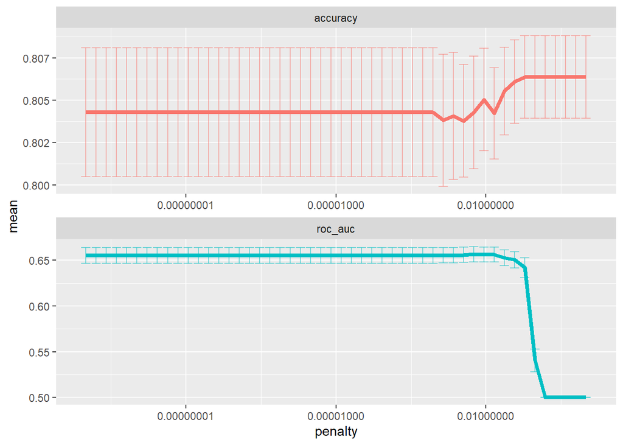

```r
echo=FALSE
error=FALSE
warning=FALSE
options(scipen = 999, digits=3, max.print=999999, show.signif.stars=TRUE)
lasso_grid %>%
  collect_metrics() %>%
  ggplot(aes(penalty, mean, color = .metric)) +
  geom_errorbar(aes(
    ymin = mean - std_err,
    ymax = mean + std_err
  ),
  alpha = 0.5
  ) +
  geom_line(size = 1.5) +
  facet_wrap(~.metric, scales = "free", nrow = 2) +
  scale_x_log10() +
  theme(legend.position = "none")
```

```r
echo=FALSE
error=FALSE
warning=FALSE
options(scipen = 999, digits=3, max.print=999999, show.signif.stars=TRUE)
Best_Lasso <- lasso_grid%>%
  select_best("accuracy", "roc_auc")
```

```r
echo=FALSE
error=FALSE
warning=FALSE
options(scipen = 999, digits=3, max.print=999999, show.signif.stars=TRUE)
#Finalize the workoflow with the best LASSO
final_wflow_Lasso <-Lasso_workflow_T%>%
  finalize_workflow(Best_Lasso)
#Check the fit of the final Wflow on the training data
Tuned_Lasso_fit<-final_wflow_Lasso%>%fit(train_data_GD_b)
Tuned_Lasso_fit
```

```
## == Workflow [trained] ==========================================================
## Preprocessor: Recipe
## Model: multinom_reg()
##
## -- Preprocessor ----------------------------------------------------------------
## 8 Recipe Steps
##
## * step_smote()
## * step_dummy()
## * step_zv()
## * step_nzv()
## * step_corr()
## * step_center()
## * step_scale()
## * step_normalize()
##
## -- Model -----------------------------------------------------------------------
##
## Call:  glmnet::glmnet(x = maybe_matrix(x), y = y, family = "multinomial",      alpha = ~1)
##
##    Df %Dev Lambda
## 1   0 0.00 0.0841
## 2   1 0.75 0.0767
## 3   1 1.37 0.0698
## 4   1 1.89 0.0636
## 5   1 2.32 0.0580
## 6   1 2.67 0.0528
## 7   1 2.97 0.0481
## 8   1 3.22 0.0439
## 9   1 3.43 0.0400
## 10  1 3.60 0.0364
## 11  1 3.74 0.0332
## 12  1 3.86 0.0302
## 13  1 3.96 0.0275
## 14  2 4.08 0.0251
## 15  3 4.38 0.0229
## 16  3 4.66 0.0208
## 17  3 4.90 0.0190
## 18  3 5.10 0.0173
## 19  3 5.26 0.0158
```

[output cut: 15 more lines]

```
## 35  4 6.03 0.0036
## 36  4 6.04 0.0032
## 37  4 6.05 0.0030
## 38  4 6.06 0.0027
## 39  4 6.06 0.0024
## 40  4 6.07 0.0022
## 41  4 6.07 0.0020
## 42  4 6.08 0.0019
## 43  4 6.08 0.0017
## 44  4 6.08 0.0015
## 45  4 6.08 0.0014
## 46  4 6.09 0.0013
##
## ...
## and 3 more lines.
```

```r
echo=FALSE
error=FALSE
warning=FALSE
options(scipen = 999, digits=3, max.print=999999, show.signif.stars=TRUE)
#Test the tuned Lasso on the test data
results_tuned_Lasso<-test_data_GD_b%>% select(GDDiag) %>%
  bind_cols(Tuned_Lasso_fit%>%
              predict(new_data = test_data_GD_b)) %>%
  bind_cols(Tuned_Lasso_fit%>%
              predict(new_data = test_data_GD_b, type = "prob"))
kable(results_tuned_Lasso)
```

| GDDiag | .pred_class | .pred_No | .pred_Yes |
| --- | --- | --- | --- |
| Yes | No | 0.740 | 0.260 |
| No | No | 0.813 | 0.187 |
| No | No | 0.797 | 0.203 |
| No | No | 0.824 | 0.176 |
| No | No | 0.829 | 0.171 |
| No | No | 0.808 | 0.192 |
| No | No | 0.779 | 0.221 |
| No | No | 0.791 | 0.209 |
| No | No | 0.797 | 0.203 |
| No | No | 0.802 | 0.198 |
| No | No | 0.839 | 0.161 |
| No | No | 0.839 | 0.161 |
| No | No | 0.802 | 0.198 |
| No | No | 0.791 | 0.209 |
| No | No | 0.773 | 0.227 |
| No | No | 0.740 | 0.260 |
| No | No | 0.819 | 0.181 |
| No | No | 0.824 | 0.176 |
| No | No | 0.839 | 0.161 |
| No | No | 0.829 | 0.171 |
| No | No | 0.839 | 0.161 |
| No | No | 0.802 | 0.198 |
| No | No | 0.839 | 0.161 |
| No | No | 0.773 | 0.227 |
| No | No | 0.813 | 0.187 |
| No | No | 0.791 | 0.209 |
| No | No | 0.785 | 0.215 |
| No | No | 0.819 | 0.181 |
| Yes | No | 0.747 | 0.253 |
| No | No | 0.813 | 0.187 |

[output cut: 105 more lines]

```r
#Tuned Lasso_Results
results_tuned_Lasso %>%
  conf_mat(truth = GDDiag, estimate = .pred_class)
```

```
##           Truth
## Prediction  No Yes
##        No  109  26
##        Yes   0   0
```

```r
#visualise CF
update_geom_defaults(geom = "rect", new = list(fill = "midnightblue", alpha = 0.7))
results_tuned_Lasso %>%
  conf_mat(GDDiag, .pred_class) %>%
  autoplot()
```

[output not shown]

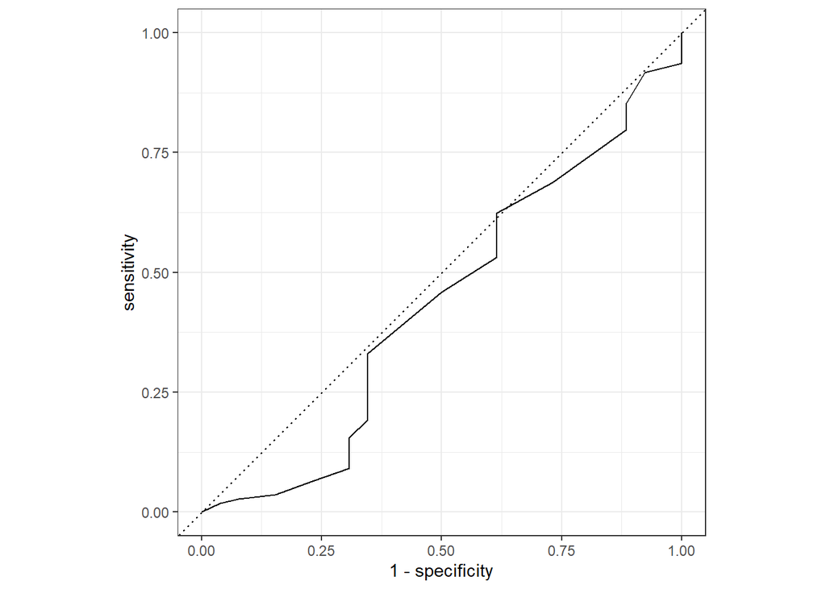

```r
#Plot Roc_Curve
curve_Lasso_tuned <- results_tuned_Lasso %>%
  roc_curve(GDDiag, .pred_Yes) %>%
  autoplot
curve_Lasso_tuned
```

```r
echo=FALSE
error=FALSE
warning=FALSE
options(scipen = 999, digits=3, max.print=999999, show.signif.stars=TRUE)
# Evaluate ROC_AOC
auc_Lasso_tuned <- results_tuned_Lasso %>%
  roc_auc(GDDiag, .pred_Yes)
auc_Lasso_tuned
```

```
## # A tibble: 1 x 3
##   .metric .estimator .estimate
##   <chr>   <chr>          <dbl>
## 1 roc_auc binary         0.433
```

```r
ev_met1_TunLasso<-ev_met1(results_tuned_Lasso,truth = GDDiag, estimate = .pred_class)
Rec_TLasso<-yardstick::recall(results_tuned_Lasso, GDDiag, .pred_class)
ACC_TLasso<-yardstick::accuracy(results_tuned_Lasso, GDDiag, .pred_class)
TunLassoMET<-list(auc_Lasso_tuned,ev_met1_TunLasso, Rec_TLasso, ACC_TLasso)
kable(TunLassoMET)
```

| .metric | .estimator | .estimate |
| --- | --- | --- |
| roc_auc | binary | 0.433 |

| .metric | .estimator | .estimate |
| --- | --- | --- |
| ppv | binary | 0.807 |
| f_meas | binary | 0.893 |

| .metric | .estimator | .estimate |
| --- | --- | --- |
| recall | binary | 1 |

| .metric | .estimator | .estimate |
| --- | --- | --- |
| accuracy | binary | 0.807 |

```r
echo=FALSE
error=FALSE
warning=FALSE
options(scipen = 999, digits=3, max.print=999999, show.signif.stars=TRUE)

set.seed(123)
#Naive Bayes

#first creating a tuning model
tune_NB <- naive_Bayes(smoothness = tune(), Laplace = tune ())%>%
  set_mode("classification")%>%
  set_engine("naivebayes")


#second creating a tuning workflow
NB_workflow_T<-workflow()%>%
  add_recipe(GD_rec) %>%
  add_model(tune_NB)
#third calling the workflow
NB_workflow_T
```

```
## == Workflow ====================================================================
## Preprocessor: Recipe
## Model: naive_Bayes()
##
## -- Preprocessor ----------------------------------------------------------------
## 8 Recipe Steps
##
## * step_smote()
## * step_dummy()
## * step_zv()
## * step_nzv()
## * step_corr()
## * step_center()
## * step_scale()
## * step_normalize()
##
## -- Model -----------------------------------------------------------------------
## Naive Bayes Model Specification (classification)
##
## Main Arguments:
##   smoothness = tune()
##   Laplace = tune()
##
## Computational engine: naivebayes
```

```r
# fourth tuning/testing the workflow to the resamples
set.seed(345)
NB_grid <- grid_regular(parameters(tune_NB), levels = 20)

NB_res<- tune_grid(
  NB_workflow_T,
  resamples = train_boot,
  grid = NB_grid)
```

```r
#Collect metrics
echo=FALSE
error=FALSE
warning=FALSE
options(scipen = 999, digits=3, max.print=999999, show.signif.stars=TRUE)

set.seed(123)
NB_res%>%
  collect_metrics() %>%
  slice_head(n = 10)
```

```
## # A tibble: 10 x 8
##    smoothness Laplace .metric  .estimator  mean     n std_err .config
##         <dbl>   <dbl> <chr>    <chr>      <dbl> <int>   <dbl> <chr>
##  1      0.5         0 accuracy binary     0.771    25 0.00458 Preprocessor1_Mod~
##  2      0.5         0 roc_auc  binary     0.540    25 0.00892 Preprocessor1_Mod~
##  3      0.553       0 accuracy binary     0.775    25 0.00481 Preprocessor1_Mod~
##  4      0.553       0 roc_auc  binary     0.541    25 0.00907 Preprocessor1_Mod~
##  5      0.605       0 accuracy binary     0.774    25 0.00501 Preprocessor1_Mod~
##  6      0.605       0 roc_auc  binary     0.541    25 0.00888 Preprocessor1_Mod~
##  7      0.658       0 accuracy binary     0.774    25 0.00480 Preprocessor1_Mod~
##  8      0.658       0 roc_auc  binary     0.543    25 0.00874 Preprocessor1_Mod~
##  9      0.711       0 accuracy binary     0.775    25 0.00496 Preprocessor1_Mod~
## 10      0.711       0 roc_auc  binary     0.546    25 0.00881 Preprocessor1_Mod~
```

```r
echo=FALSE
error=FALSE
warning=FALSE
options(scipen = 999, digits=3, max.print=999999, show.signif.stars=TRUE)
best_NB <- NB_res %>%
  select_best("accuracy", "roc_auc")
best_NB
```

```
## # A tibble: 1 x 3
##   smoothness Laplace .config
##        <dbl>   <dbl> <chr>
## 1       1.45       0 Preprocessor1_Model019
```

```r
echo=FALSE
error=FALSE
warning=FALSE
options(scipen = 999, digits=3, max.print=999999, show.signif.stars=TRUE)
#11th Finalize the workoflow with the best model
final_wflow_NB <- NB_workflow_T %>%
  finalize_workflow(best_NB)
#12th Check the fit of the final Wflow on the training data
Tuned_NB_fit<-final_wflow_NB%>%fit(train_data_GD_b)
Tuned_NB_fit
```

```
## == Workflow [trained] ==========================================================
## Preprocessor: Recipe
## Model: naive_Bayes()
##
## -- Preprocessor ----------------------------------------------------------------
## 8 Recipe Steps
##
## * step_smote()
## * step_dummy()
## * step_zv()
## * step_nzv()
## * step_corr()
## * step_center()
## * step_scale()
## * step_normalize()
##
## -- Model -----------------------------------------------------------------------
##
## ================================== Naive Bayes ==================================
##
##  Call:
## naive_bayes.default(x = maybe_data_frame(x), y = y, laplace = ~0,
##     usekernel = TRUE, adjust = ~1.44736842105263)
##
## ---------------------------------------------------------------------------------
##
## Laplace smoothing: 0
##
## ---------------------------------------------------------------------------------
##
##  A priori probabilities:
##
##  No Yes
## 0.8 0.2
##
## ---------------------------------------------------------------------------------
##
##  Tables:
##
## ---------------------------------------------------------------------------------
```

[output cut: 15 more lines]

```
##
## ---------------------------------------------------------------------------------
##  ::: IDTotal::Yes (KDE)
## ---------------------------------------------------------------------------------
##
## Call:
##  density.default(x = x, adjust = ..1, na.rm = TRUE)
##
## Data: x (81 obs.);   Bandwidth 'bw' = 0.5782
##
##        x               y
##  Min.   :-3.16   Min.   :0.0001
##
## ...
## and 110 more lines.
```

```r
echo=FALSE
error=FALSE
warning=FALSE
options(scipen = 999, digits=3, max.print=999999, show.signif.stars=TRUE)
#Test the tuned NB on the test data
results_tuned_NB<-test_data_GD_b %>% select(GDDiag) %>%
  bind_cols (Tuned_NB_fit%>%
              predict(new_data = test_data_GD_b)) %>%
  bind_cols(Tuned_NB_fit%>%
              predict(new_data = test_data_GD_b, type = "prob"))
kable(results_tuned_NB)
```

| GDDiag | .pred_class | .pred_No | .pred_Yes |
| --- | --- | --- | --- |
| Yes | No | 0.651 | 0.349 |
| No | No | 0.815 | 0.185 |
| No | No | 0.784 | 0.216 |
| No | No | 0.936 | 0.064 |
| No | No | 0.922 | 0.078 |
| No | No | 0.846 | 0.154 |
| No | No | 0.762 | 0.238 |
| No | No | 0.766 | 0.234 |
| No | No | 0.892 | 0.108 |
| No | No | 0.840 | 0.160 |
| No | No | 0.933 | 0.067 |
| No | No | 0.938 | 0.062 |
| No | No | 0.856 | 0.144 |
| No | No | 0.844 | 0.156 |
| No | No | 0.773 | 0.227 |
| No | Yes | 0.125 | 0.875 |
| No | No | 0.607 | 0.393 |
| No | No | 0.924 | 0.076 |
| No | No | 0.953 | 0.047 |
| No | No | 0.879 | 0.121 |
| No | No | 0.938 | 0.062 |
| No | No | 0.839 | 0.161 |
| No | No | 0.938 | 0.062 |
| No | No | 0.822 | 0.178 |
| No | No | 0.897 | 0.103 |
| No | No | 0.870 | 0.130 |
| No | No | 0.887 | 0.113 |
| No | No | 0.909 | 0.091 |
| Yes | Yes | 0.251 | 0.749 |
| No | No | 0.910 | 0.090 |

[output cut: 105 more lines]

```r
echo=FALSE
error=FALSE
warning=FALSE
options(scipen = 999, digits=3, max.print=999999, show.signif.stars=TRUE)
#Tuned NB_Results
results_tuned_NB %>%
  conf_mat(truth = GDDiag, estimate = .pred_class)
```

```
##           Truth
## Prediction  No Yes
##        No  106  24
##        Yes   3   2
```

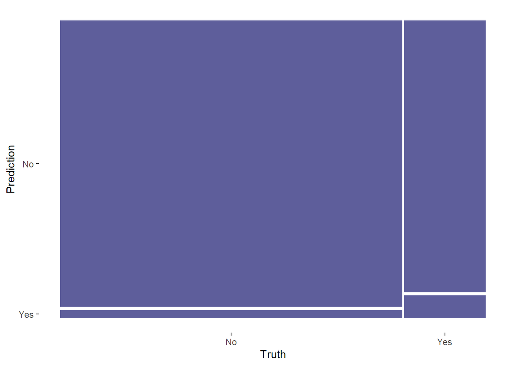

```r
#visualise CF
update_geom_defaults(geom = "rect", new = list(fill = "midnightblue", alpha = 0.7))
results_tuned_NB %>%
  conf_mat(GDDiag, .pred_class) %>%
  autoplot()
```

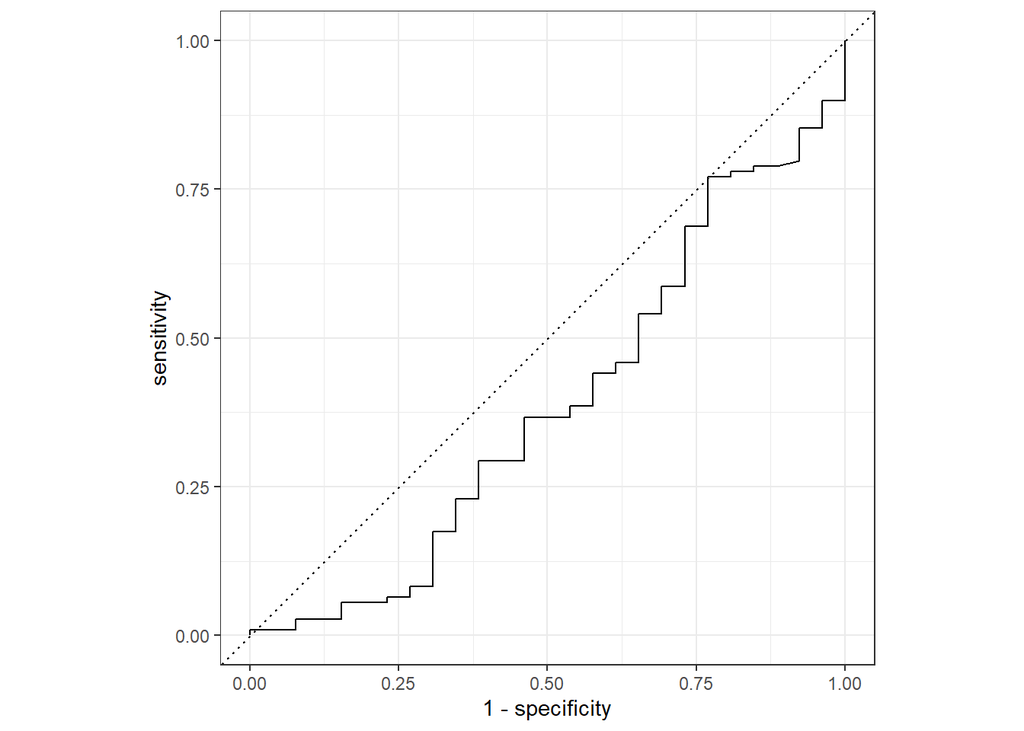

```r
echo=FALSE
error=FALSE
warning=FALSE
options(scipen = 999, digits=3, max.print=999999, show.signif.stars=TRUE)
#Plot Roc_Curve
curve_NB_tuned <- results_tuned_NB %>%
  roc_curve(GDDiag, .pred_Yes) %>%
  autoplot
curve_NB_tuned
```

```r
echo=FALSE
error=FALSE
warning=FALSE
options(scipen = 999, digits=3, max.print=999999, show.signif.stars=TRUE)
# Evaluate ROC_AUC
auc_NB_tuned <- results_tuned_NB %>%
  roc_auc(GDDiag, .pred_Yes)
auc_NB_tuned
```

```
## # A tibble: 1 x 3
##   .metric .estimator .estimate
##   <chr>   <chr>          <dbl>
## 1 roc_auc binary         0.386
```

```r
echo=FALSE
error=FALSE
warning=FALSE
options(scipen = 999, digits=3, max.print=999999, show.signif.stars=TRUE)
ev_met1_TunNB<-ev_met1(results_tuned_NB,truth = GDDiag, estimate = .pred_class)
Rec_TNB<-yardstick::recall(results_tuned_NB, GDDiag, .pred_class)
ACC_TNB<-yardstick::accuracy(results_tuned_NB, GDDiag, .pred_class)
TunNBMET<-list(auc_NB_tuned,ev_met1_TunNB, Rec_TNB, ACC_TNB)
kable(TunNBMET)
```

| .metric | .estimator | .estimate |
| --- | --- | --- |
| roc_auc | binary | 0.386 |

| .metric | .estimator | .estimate |
| --- | --- | --- |
| ppv | binary | 0.815 |
| f_meas | binary | 0.887 |

| .metric | .estimator | .estimate |
| --- | --- | --- |
| recall | binary | 0.972 |

| .metric | .estimator | .estimate |
| --- | --- | --- |
| accuracy | binary | 0.8 |

```r
echo=FALSE
error=FALSE
warning=FALSE
options(scipen = 999, digits=3, max.print=999999, show.signif.stars=TRUE)

set.seed(123)
#Logistic Regression

#first creating a tuning model
tune_LR <- logistic_reg(penalty = tune(), mixture = tune())%>%
  set_mode("classification")%>%
  set_engine("glmnet")


#second creating a tuning workflow
LR_workflow_T<-workflow()%>%
  add_recipe(GD_rec) %>%
  add_model(tune_LR)
#third calling the workflow
LR_workflow_T
```

```
## == Workflow ====================================================================
## Preprocessor: Recipe
## Model: logistic_reg()
##
## -- Preprocessor ----------------------------------------------------------------
## 8 Recipe Steps
##
## * step_smote()
## * step_dummy()
## * step_zv()
## * step_nzv()
## * step_corr()
## * step_center()
## * step_scale()
## * step_normalize()
##
## -- Model -----------------------------------------------------------------------
## Logistic Regression Model Specification (classification)
##
## Main Arguments:
##   penalty = tune()
##   mixture = tune()
##
## Computational engine: glmnet
```

```r
set.seed(345)
echo=FALSE
error=FALSE
warning=FALSE
options(scipen = 999, digits=3, max.print=999999, show.signif.stars=TRUE)

LR_grid <- grid_regular(parameters(tune_LR), levels = 20)

LR_res<- tune_grid(
  LR_workflow_T,
  resamples = train_boot,
  grid = LR_grid)

LR_res
```

```
## # Tuning results
## # Bootstrap sampling using stratification
## # A tibble: 25 x 4
##    splits            id          .metrics           .notes
##    <list>            <chr>       <list>             <list>
##  1 <split [403/154]> Bootstrap01 <tibble [800 x 6]> <tibble [0 x 3]>
##  2 <split [403/142]> Bootstrap02 <tibble [800 x 6]> <tibble [0 x 3]>
##  3 <split [403/160]> Bootstrap03 <tibble [800 x 6]> <tibble [0 x 3]>
##  4 <split [403/147]> Bootstrap04 <tibble [800 x 6]> <tibble [0 x 3]>
##  5 <split [403/163]> Bootstrap05 <tibble [800 x 6]> <tibble [0 x 3]>
##  6 <split [403/140]> Bootstrap06 <tibble [800 x 6]> <tibble [0 x 3]>
##  7 <split [403/148]> Bootstrap07 <tibble [800 x 6]> <tibble [0 x 3]>
##  8 <split [403/146]> Bootstrap08 <tibble [800 x 6]> <tibble [0 x 3]>
##  9 <split [403/153]> Bootstrap09 <tibble [800 x 6]> <tibble [0 x 3]>
## 10 <split [403/142]> Bootstrap10 <tibble [800 x 6]> <tibble [0 x 3]>
## # i 15 more rows
```

```r
echo=FALSE
error=FALSE
warning=FALSE
options(scipen = 999, digits=3, max.print=999999, show.signif.stars=TRUE)

set.seed(123)
LR_res%>%
  collect_metrics() %>%
  slice_head(n = 10)
```

```
## # A tibble: 10 x 8
##     penalty mixture .metric  .estimator  mean     n std_err .config
##       <dbl>   <dbl> <chr>    <chr>      <dbl> <int>   <dbl> <chr>
##  1 1   e-10    0.05 accuracy binary     0.804    25 0.00386 Preprocessor1_Model~
##  2 1   e-10    0.05 roc_auc  binary     0.655    25 0.00845 Preprocessor1_Model~
##  3 3.36e-10    0.05 accuracy binary     0.804    25 0.00386 Preprocessor1_Model~
##  4 3.36e-10    0.05 roc_auc  binary     0.655    25 0.00845 Preprocessor1_Model~
##  5 1.13e- 9    0.05 accuracy binary     0.804    25 0.00386 Preprocessor1_Model~
##  6 1.13e- 9    0.05 roc_auc  binary     0.655    25 0.00845 Preprocessor1_Model~
##  7 3.79e- 9    0.05 accuracy binary     0.804    25 0.00386 Preprocessor1_Model~
##  8 3.79e- 9    0.05 roc_auc  binary     0.655    25 0.00845 Preprocessor1_Model~
##  9 1.27e- 8    0.05 accuracy binary     0.804    25 0.00386 Preprocessor1_Model~
## 10 1.27e- 8    0.05 roc_auc  binary     0.655    25 0.00845 Preprocessor1_Model~
```

```r
echo=FALSE
error=FALSE
warning=FALSE
options(scipen = 999, digits=3, max.print=999999, show.signif.stars=TRUE)
best_LR <- LR_res %>%
  select_best("accuracy", "roc_auc")
best_LR
```

```
## # A tibble: 1 x 3
##   penalty mixture .config
##     <dbl>   <dbl> <chr>
## 1   0.298    0.05 Preprocessor1_Model019
```

```r
echo=FALSE
error=FALSE
warning=FALSE
options(scipen = 999, digits=3, max.print=999999, show.signif.stars=TRUE)
#11th Finalize the workoflow with the best model
final_wflow_LR <- LR_workflow_T %>%
  finalize_workflow(best_LR)
#12th Check the fit of the final Wflow on the training data
Tuned_LR_fit<-final_wflow_LR%>%fit(train_data_GD_b)
Tuned_LR_fit
```

```
## == Workflow [trained] ==========================================================
## Preprocessor: Recipe
## Model: logistic_reg()
##
## -- Preprocessor ----------------------------------------------------------------
## 8 Recipe Steps
##
## * step_smote()
## * step_dummy()
## * step_zv()
## * step_nzv()
## * step_corr()
## * step_center()
## * step_scale()
## * step_normalize()
##
## -- Model -----------------------------------------------------------------------
##
## Call:  glmnet::glmnet(x = maybe_matrix(x), y = y, family = "binomial",      alpha = ~0.05)
##
##    Df %Dev Lambda
## 1   0 0.00  1.680
## 2   1 0.08  1.530
## 3   1 0.16  1.400
## 4   1 0.25  1.270
## 5   1 0.34  1.160
## 6   1 0.44  1.060
## 7   1 0.55  0.963
## 8   1 0.66  0.877
## 9   1 0.77  0.799
## 10  1 0.89  0.728
## 11  1 1.02  0.664
## 12  1 1.15  0.605
## 13  1 1.28  0.551
## 14  2 1.43  0.502
## 15  2 1.57  0.457
## 16  2 1.72  0.417
## 17  2 1.88  0.380
## 18  2 2.02  0.346
## 19  2 2.17  0.315
```

[output cut: 15 more lines]

```
## 35  4 4.79  0.071
## 36  4 4.92  0.065
## 37  4 5.03  0.059
## 38  4 5.14  0.054
## 39  4 5.25  0.049
## 40  4 5.34  0.045
## 41  4 5.42  0.041
## 42  4 5.50  0.037
## 43  4 5.57  0.034
## 44  4 5.64  0.031
## 45  4 5.69  0.028
## 46  4 5.74  0.026
##
## ...
## and 27 more lines.
```

```r
echo=FALSE
error=FALSE
warning=FALSE
options(scipen = 999, digits=3, max.print=999999, show.signif.stars=TRUE)
#Test the tuned NB on the test data
results_tuned_LR<-test_data_GD_b %>% select(GDDiag) %>%
  bind_cols (Tuned_LR_fit%>%
              predict(new_data = test_data_GD_b)) %>%
  bind_cols(Tuned_LR_fit%>%
              predict(new_data = test_data_GD_b, type = "prob"))
kable(results_tuned_LR)
```

| GDDiag | .pred_class | .pred_No | .pred_Yes |
| --- | --- | --- | --- |
| Yes | No | 0.739 | 0.261 |
| No | No | 0.813 | 0.187 |
| No | No | 0.795 | 0.205 |
| No | No | 0.825 | 0.175 |
| No | No | 0.832 | 0.168 |
| No | No | 0.812 | 0.188 |
| No | No | 0.777 | 0.223 |
| No | No | 0.788 | 0.212 |
| No | No | 0.797 | 0.203 |
| No | No | 0.802 | 0.198 |
| No | No | 0.843 | 0.157 |
| No | No | 0.843 | 0.157 |
| No | No | 0.802 | 0.198 |
| No | No | 0.791 | 0.209 |
| No | No | 0.771 | 0.229 |
| No | No | 0.735 | 0.265 |
| No | No | 0.815 | 0.185 |
| No | No | 0.826 | 0.174 |
| No | No | 0.841 | 0.159 |
| No | No | 0.826 | 0.174 |
| No | No | 0.843 | 0.157 |
| No | No | 0.802 | 0.198 |
| No | No | 0.843 | 0.157 |
| No | No | 0.773 | 0.227 |
| No | No | 0.813 | 0.187 |
| No | No | 0.792 | 0.208 |
| No | No | 0.785 | 0.215 |
| No | No | 0.819 | 0.181 |
| Yes | No | 0.744 | 0.256 |
| No | No | 0.814 | 0.186 |

[output cut: 105 more lines]

```r
echo=FALSE
error=FALSE
warning=FALSE
options(scipen = 999, digits=3, max.print=999999, show.signif.stars=TRUE)
#Tuned NB_Results
results_tuned_LR %>%
  conf_mat(truth = GDDiag, estimate = .pred_class)
```

```
##           Truth
## Prediction  No Yes
##        No  109  26
##        Yes   0   0
```

```r
#visualise CF
update_geom_defaults(geom = "rect", new = list(fill = "midnightblue", alpha = 0.7))
results_tuned_LR %>%
  conf_mat(GDDiag, .pred_class) %>%
  autoplot()
```

[output not shown]

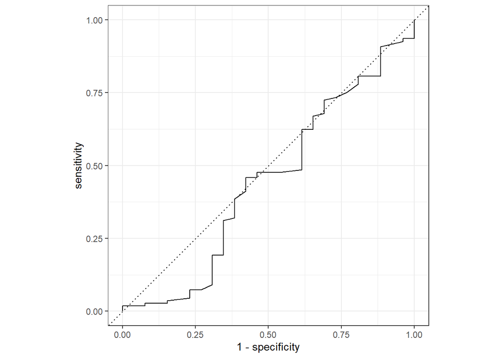

```r
echo=FALSE
error=FALSE
warning=FALSE
options(scipen = 999, digits=3, max.print=999999, show.signif.stars=TRUE)
#Plot Roc_Curve
curve_LR_tuned <- results_tuned_LR%>%
  roc_curve(GDDiag, .pred_Yes) %>%
  autoplot
curve_LR_tuned
```

```r
echo=FALSE
error=FALSE
warning=FALSE
options(scipen = 999, digits=3, max.print=999999, show.signif.stars=TRUE)
# Evaluate ROC_AUC
auc_LR_tuned <- results_tuned_LR %>%
  roc_auc(GDDiag, .pred_Yes)
auc_LR_tuned
```

```
## # A tibble: 1 x 3
##   .metric .estimator .estimate
##   <chr>   <chr>          <dbl>
## 1 roc_auc binary         0.444
```

```r
echo=FALSE
error=FALSE
warning=FALSE
options(scipen = 999, digits=3, max.print=999999, show.signif.stars=TRUE)
ev_met1_TunLR<-ev_met1(results_tuned_LR,truth = GDDiag, estimate = .pred_class)
Rec_TLR<-yardstick::recall(results_tuned_LR, GDDiag, .pred_class)
ACC_TLR<-yardstick::accuracy(results_tuned_LR, GDDiag, .pred_class)
TunLRMET<-list(auc_LR_tuned,ev_met1_TunLR, Rec_TLR, ACC_TLR)
kable(TunLRMET)
```

| .metric | .estimator | .estimate |
| --- | --- | --- |
| roc_auc | binary | 0.444 |

| .metric | .estimator | .estimate |
| --- | --- | --- |
| ppv | binary | 0.807 |
| f_meas | binary | 0.893 |

| .metric | .estimator | .estimate |
| --- | --- | --- |
| recall | binary | 1 |

| .metric | .estimator | .estimate |
| --- | --- | --- |
| accuracy | binary | 0.807 |